# Predicting Human Fecal Contamination of Produce Irrigation Water

- Show All Code
- Hide All Code
- View Source

Version 4.2

Published

February 11, 2026

# Description

**R** code to conduct the analysis of human fecal contamination in produce irrigation ponds using predictive models that is reported in:

> Hofstetter J, Holcomb DA, Kahler AM, Rodrigues C, da Silva ALBR, Mattioli MC. (2024). Performance of conditional random forest and regression models at predicting human fecal contamination of produce irrigation ponds in the southeastern United States. *ACS ES&T Water*. https://doi.org/10.1021/acsestwater.4c00839.

This analysis [code](https://cdcgov.github.io/EMEL/manuscripts/irrigation_models/) and the study [data](https://cdcgov.github.io/EMEL/manuscripts/irrigation_models/pond_data.csv) are available in the manuscript [repository](https://github.com/CDCgov/EMEL/tree/main/manuscripts/irrigation_models).

**Setup**

Load packages and set options.

```r
## Options
options(tidyverse.quiet = TRUE)
options(dplyr.summarise.inform = FALSE)
options(knitr.kable.NA = '')

## Packages
# Utilities
library(readxl)       # I/O
library(lubridate)    # date formatting
library(broman)       # number formatting
library(zoo)          # time series data

# Models
library(lme4)         # mixed effect regression models
library(party)        # conditional random forest models
library(mlr)          # framework for ML model development
library(broom)        # extract model estimates
library(broom.mixed)  # extract model estimates (lme4)
#library(pROC)        # ROC curve analysis (conflicts, call functions directly)

# Graphs
library(corrplot)     # plotting correlations
library(patchwork)    # combine plots
library(ggh4x)        # nested facets
library(ragg)         # more consistent graphics output

# Tidyverse
library(knitr)        # rendering
library(quarto)       # rendering
library(tidyverse)    # load last to avoid conflicts (particularly with data.table)

## Define general functions
`%notin%` = function(x,y) !(x %in% y)
```

# Data

We have two separate datasets from the same growing region. The first, collected in 2020-2021, is used to tune and train the predictive models of fecal contamination. The second, collected in 2015-2016, is used only as a test dataset to assess the predictive performance of the models. The data are provided in a single file. Read the file, transform certain variables for analysis, and save separately in RDS format for convenience.

```r
## read combined dataset
df_all_raw <- data.table::fread("../out/pond_data.csv")

## transform variables for analysis
df_all <- df_all_raw %>%
  mutate(dt_collect = as_date(dt_collect),
         turb = log10(turb + 1),
         cond = log10(cond),
         across(starts_with("solar"), ~log10(.x)))

## save transformed training data
df_train <- df_all %>%
  filter(set == "train")
saveRDS(df_train, "../out/data_train.rds")

## save transformed test data
df_test <- df_all %>%
  filter(set == "test")
saveRDS(df_test, "../out/data_test.rds")
```

# Train Models

## Correlation

Explanatory variables considered for inclusion in both types of models are first screened for pairwise correlations; variable pairs with correlation absolute values ≥0.5 are not included in the same models. Estimate pairwise Pearson correlations between all explanatory variables and plot a correlogram.

```r
## labels
cor_var <- c("building", "week",
             "rain2", "rain7",
             "solar2", "solar7",
             "wind2", "wind7",
             "temp", "ph", "do",
             "cond", "turb")

cor_lab <- read_xlsx("../data/variable_names.xlsx") %>%
  filter(term %in% cor_var) %>%
  mutate(term = fct_relevel(term, cor_var)) %>%
  arrange(term) %>%
  select(label) %>%
  pull()


## variables to correlate
df_train_corr <- readRDS("../out/data_train.rds") %>%
  select(building, week,
         rain2, rain7,
         solar2, solar7,
         wind2, wind7,
         temp, ph, do,
         cond, turb)

names(df_train_corr) <- cor_lab

## calculate correlations
cormat <- cor(df_train_corr)

## prepare correlation plot
corlist <- corrplot(cormat,
                    type = "upper", method = 'number',
                    order = "hclust", addrect = 3,
                    tl.col = "black", tl.srt = 45,
                    number.cex = 0.8)$corrPos
```

[figure not shown]

```r
## identify highly correlated (positive or negative) variables
cor_hi <- corlist %>%
  mutate(corr_abs = abs(corr),
         corr_coarse = round(corr_abs, 1)) %>%
  filter(corr_coarse >= 0.5,
         !(xName == yName))
```

Unsurprisingly, we see high correlations (> 0.5 absolute value) for both solar variables and temperature. Solar 0-2 has a slightly higher association with temperature than Solar 2-7 does, so if we only include Solar 0-2 in the multivariable models (excluding both Solar 2-7 and temperature) then we should capture more of the influence of both the excluded variables while avoided highly correlated predictors. Additionally, pH and dissolved oxygen are fairly highly correlated at 0.47, but do not quite exceed the 0.5 correlation threshold.

Also examine associations between the outcome variables by Cochran-Mantel-Haenszel chi-squared test stratified by pond.

```r
## HF183 & crAssphage
tab_hf_crass <- readRDS("../out/data_train.rds") %>%
  select(hf183, phage, pond) %>%
  table()

mantelhaen.test(tab_hf_crass)
```

```
    Mantel-Haenszel chi-squared test with continuity correction

data:  tab_hf_crass
Mantel-Haenszel X-squared = 5.1106, df = 1, p-value = 0.02378
alternative hypothesis: true common odds ratio is not equal to 1
95 percent confidence interval:
  1.356967 18.170199
sample estimates:
common odds ratio
         4.965517
```

```r
## HF183 & E. coli > 126
tab_hf_ec <- readRDS("../out/data_train.rds") %>%
  select(hf183, ecoli, pond) %>%
  table()

mantelhaen.test(tab_hf_ec)
```

```
    Mantel-Haenszel chi-squared test with continuity correction

data:  tab_hf_ec
Mantel-Haenszel X-squared = 1.8212, df = 1, p-value = 0.1772
alternative hypothesis: true common odds ratio is not equal to 1
95 percent confidence interval:
 0.7617406 6.4196774
sample estimates:
common odds ratio
         2.211364
```

## Regression

Logistic regression models are implemented as generalized linear mixed models (GLMM) to account for repeated measures at each pond. Univariable models are first fit for each outcome/explanatory variable pair to screen for association. Multivariable models are then fit for each outcome including the explanatory variables with univariable $p < 0.1$ and backwards elimination is used to obtain the final explanatory variable sets.

### Univariable

Fit a univariable model for each combination of explanatory variable and outcome, including pond as a random effect.

```r
## long data
df_reg_uni <- readRDS("../out/data_train.rds") %>%
  select(pond,
         week, building,
         temp, turb,
         cond, do, ph,
         rain2, rain7,
         solar2, solar7,
         wind2, wind7,
         ecoli, hf183, hfi) %>%
  pivot_longer(c(ecoli, hf183, hfi),
               names_to = "outcome",
               values_to = "detect") %>%
  pivot_longer(c(week, building, temp, turb, cond, do, ph,
                 rain2, rain7, solar2, solar7, wind2, wind7),
               names_to = "predictor",
               values_to = "value")


## fit
fit_reg_uni <- df_reg_uni %>%
  group_by(outcome, predictor) %>%
  nest() %>%
  mutate(fit = map(data,
                   ~glmer(formula = detect ~ value + (1 | pond),
                          data = .x,
                          family = binomial(link = "logit"),
                          control = glmerControl(optimizer = "bobyqa",
                                                 optCtrl = list(maxfun = 2e5)))),
         est = map(fit, ~tidy(.x, exponentiate = TRUE, conf.int = TRUE))) %>%
  ungroup()
saveRDS(fit_reg_uni, "../fit/reg_uni.rds")

## Estimates
est_reg_uni <- fit_reg_uni %>%
  select(outcome, predictor, est) %>%
  unnest(est)
saveRDS(est_reg_uni, "../out/est_reg_uni.rds")


## filter for only explanatory variables with p < 0.1 to include in multivariable models
# variable names
est_reg_p0.1 <- est_reg_uni %>%
  filter(term == "value") %>%
  left_join(read_xlsx("../data/variable_names.xlsx"),
            by = c("predictor" = "term")) %>%
  mutate(outcome = fct_relevel(outcome, c("hf183", "hfi", "ecoli")),
         predictor = fct_relevel(predictor,
                                 c("building", "week",
                                   "rain2", "rain7",
                                   "solar2", "solar7",
                                   "wind2", "wind7",
                                   "temp", "ph", "do",
                                   "cond", "turb"))) %>%
  arrange(outcome, predictor) %>%
  filter(p.value < 0.1)
```

Plot the univariable associations.

```r
## estimates
# variable names
var_lab <- read_xlsx("../data/variable_names.xlsx")

# raw
est_reg_uni <- readRDS("../out/est_reg_uni.rds")

# format
df_plot_reg_uni <- est_reg_uni %>%
  filter(term == "value") %>%
  left_join(var_lab, by = c("predictor" = "term")) %>%
  mutate(predictor = fct_relevel(predictor,
                                 c("building", "week",
                                   "rain2", "rain7",
                                   "solar2", "solar7",
                                   "wind2", "wind7",
                                   "temp", "ph", "do",
                                   "cond", "turb"))) %>%
  arrange(predictor) %>%
  mutate(label = fct_inorder(label) %>%
           fct_recode("Dissolved\noxygen" = "Dissolved oxygen") %>%
           fct_rev(),
         signif = case_when(p.value < 0.01 ~ "p < 0.01",
                            p.value >= 0.01 & p.value < 0.05 ~ "p < 0.05",
                            p.value >= 0.05 & p.value < 0.1 ~ "p < 0.1",
                            p.value >= 0.1 ~ "p ≥ 0.1",
                            TRUE ~ NA_character_) %>%
           fct_relevel(c("p < 0.01", "p < 0.05", "p < 0.1")),
         out_lab = fct_relevel(outcome, c("hf183", "hfi", "ecoli")) %>%
           fct_recode("(A) HF183 detection" = "hf183",
                      "(B) HFI detection" = "hfi",
                      "(C) *E. coli* ≥126 MPN/100 mL" = "ecoli"))


p_or_uni <- df_plot_reg_uni %>%
  ggplot(aes(x = estimate, y = label, color = signif)) +
  facet_grid(cols = vars(out_lab)) +
  geom_vline(xintercept = 1, color = "red",
             linetype = "dashed", linewidth = 1,
             alpha = 0.5) +
  geom_point(shape = 18, size = 5) +
  geom_errorbarh(aes(xmin = conf.low, xmax = conf.high),
                 height = 0.15) +
  scale_x_log10(breaks = c(0.001, 0.01, 0.1, 1, 10, 100),
                labels = c("0.001", "0.01", "0.1", "1", "10", "100")) +
  coord_cartesian(xlim = c(0.001, NA)) +
  scale_color_viridis_d(begin = 0.05, end = 0.95,
                        option = "plasma", direction = 1,
                        name = "Significance") +
  labs(x = "odds ratio",
       y = NULL) +
  theme_bw() +
  theme(strip.text = ggtext::element_markdown(hjust = 0),
        legend.position = "top",
        panel.spacing = unit(0.5, "lines"))


ggsave(filename = "../fig/forest_or_uni.jpg",
       plot = p_or_uni,
       device = ragg::agg_jpeg, dpi = 300,
       width = 8, height = 6, units = "in")
```

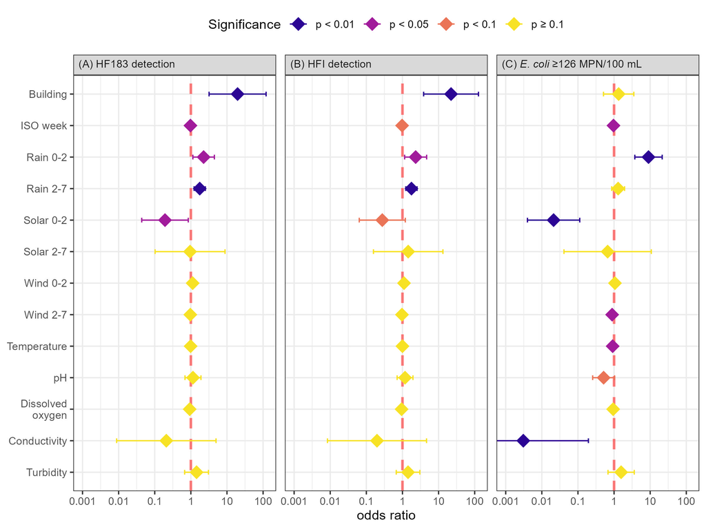

Explanatory variable associations with fecal indicator outcomes in the training dataset by univariable logistic regression models

We are retaining explanatory variables with $p < 0.1$ in the univariable models as candidates for the multivariable models. This criterion leads to the following full models:

- HF183 detection: Building, ISO week, Rain 0-2, Rain 2-7, Solar 0-2
- HFI detection: Building, ISO week, Rain 0-2, Rain 2-7, Solar 0-2
- *E. coli* ≥126 MPN/100 mL: ISO week, Rain 0-2, Solar 0-2, Wind 2-7, Temperature, pH, Conductivity

### Stepwise selection

We use backwards elimination with a criterion of $p \geq 0.1$ on a chi-square test comparing model deviance in favor of the simpler (fewer explanatory variables) model. Define a function to identify the explanatory variable with the highest p-value in a model fit, which will be dropped to form the simpler model.

```r
## function to ID highest p-value predictor
pick_hi_p <- function(fit){

  fit %>%
    tidy() %>%
    filter(effect == "fixed",
           term != "(Intercept)") %>%
    mutate(pval_hi = max(p.value)) %>%
    filter(p.value == pval_hi)

}
```

Beginning with the HF183 outcome, fit the full model with all the explanatory variables identified in the univariable analysis.

```r
## Data
df_reg <- readRDS("../out/data_train.rds")


## HF183
# full
m183_full <- glmer(hf183 ~ building + week + rain2 + rain7 + solar2 + (1 | pond),
                   data = df_reg,
                   family = binomial(link = "logit"),
                   control = glmerControl(optimizer = "bobyqa",
                                          optCtrl = list(maxfun = 2e5)))
pick_hi_p(m183_full)
```

```
# A tibble: 1 × 8
  effect group term  estimate std.error statistic p.value pval_hi
  <chr>  <chr> <chr>    <dbl>     <dbl>     <dbl>   <dbl>   <dbl>
1 fixed  <NA>  week  -0.00686    0.0143    -0.480   0.632   0.632
```

ISO Week is least significant (highest p-value), so we drop it for the next model.

```r
# reduced (-week)
m183_r1 <- glmer(hf183 ~ building + rain2 + rain7 + solar2 + (1 | pond),
                 data = df_reg,
                 family = binomial(link = "logit"),
                 control = glmerControl(optimizer = "bobyqa",
                                        optCtrl = list(maxfun = 2e5)))

# compare full and reduced models
# non-significant chi-square test means more complex model is no better than simpler model
anova(m183_full, m183_r1)
```

```
Data: df_reg
Models:
m183_r1: hf183 ~ building + rain2 + rain7 + solar2 + (1 | pond)
m183_full: hf183 ~ building + week + rain2 + rain7 + solar2 + (1 | pond)
          npar    AIC    BIC  logLik deviance  Chisq Df Pr(>Chisq)
m183_r1      6 199.66 219.94 -93.832   187.66
m183_full    7 201.44 225.10 -93.720   187.44 0.2246  1     0.6356
```

```r
pick_hi_p(m183_r1)
```

```
# A tibble: 1 × 8
  effect group term   estimate std.error statistic p.value pval_hi
  <chr>  <chr> <chr>     <dbl>     <dbl>     <dbl>   <dbl>   <dbl>
1 fixed  <NA>  solar2    -1.05     0.866     -1.22   0.224   0.224
```

The full model did not give significantly lower deviance than the simpler model, so we use the simpler model and repeat the procedure again, this time eliminating the next-highest p-value predictor, Solar 0-2.

```r
# reduced (-solar2)
m183_r2 <- glmer(hf183 ~ building + rain2 + rain7 + (1 | pond),
                 data = df_reg,
                 family = binomial(link = "logit"),
                 control = glmerControl(optimizer = "bobyqa",
                                        optCtrl = list(maxfun = 2e5)))

# compare full and reduced models
# non-significant chi-square test means more complex model is no better than simpler model
anova(m183_r1, m183_r2)
```

```
Data: df_reg
Models:
m183_r2: hf183 ~ building + rain2 + rain7 + (1 | pond)
m183_r1: hf183 ~ building + rain2 + rain7 + solar2 + (1 | pond)
        npar    AIC    BIC  logLik deviance  Chisq Df Pr(>Chisq)
m183_r2    5 199.13 216.03 -94.566   189.13
m183_r1    6 199.66 219.94 -93.832   187.66 1.4671  1     0.2258
```

```r
pick_hi_p(m183_r2)
```

```
# A tibble: 1 × 8
  effect group term  estimate std.error statistic p.value pval_hi
  <chr>  <chr> <chr>    <dbl>     <dbl>     <dbl>   <dbl>   <dbl>
1 fixed  <NA>  rain2    0.715     0.369      1.94  0.0526  0.0526
```

Again, the test was not significant, suggesting that we can safely drop the Solar 0-2 variable. Next we drop Rain 0-2, the next highest p-value variable.

```r
# reduced (-rain2)
m183_r3 <- glmer(hf183 ~ rain7 + building  + (1 | pond),
                 data = df_reg,
                 family = binomial(link = "logit"),
                 control = glmerControl(optimizer = "bobyqa",
                                        optCtrl = list(maxfun = 2e5)))

# compare full and reduced models
# non-significant chi-square test means more complex model is no better than simpler model
anova(m183_r2, m183_r3)
```

```
Data: df_reg
Models:
m183_r3: hf183 ~ rain7 + building + (1 | pond)
m183_r2: hf183 ~ building + rain2 + rain7 + (1 | pond)
        npar    AIC    BIC  logLik deviance  Chisq Df Pr(>Chisq)
m183_r3    4 200.89 214.41 -96.444   192.89
m183_r2    5 199.13 216.03 -94.566   189.13 3.7571  1    0.05258 .
---
Signif. codes:  0 '***' 0.001 '**' 0.01 '*' 0.05 '.' 0.1 ' ' 1
```

```r
pick_hi_p(m183_r3)
```

```
# A tibble: 1 × 8
  effect group term  estimate std.error statistic p.value pval_hi
  <chr>  <chr> <chr>    <dbl>     <dbl>     <dbl>   <dbl>   <dbl>
1 fixed  <NA>  rain7    0.574     0.184      3.12 0.00180 0.00180
```

This time the test is significant at the 10% level (and very nearly significant the 5% level), so we should keep Rain 0-2. Compare to an even further reduced model:

```r
# reduced (-rain7)
m183_r4 <- glmer(hf183 ~ building  + (1 | pond),
                 data = df_reg,
                 family = binomial(link = "logit"),
                 control = glmerControl(optimizer = "bobyqa",
                                        optCtrl = list(maxfun = 2e5)))

# compare full and reduced models
# non-significant chi-square test means more complex model is no better than simpler model
anova(m183_r3, m183_r4)
```

```
Data: df_reg
Models:
m183_r4: hf183 ~ building + (1 | pond)
m183_r3: hf183 ~ rain7 + building + (1 | pond)
        npar    AIC    BIC   logLik deviance  Chisq Df Pr(>Chisq)
m183_r4    3 208.34 218.48 -101.171   202.34
m183_r3    4 200.89 214.41  -96.444   192.89 9.4533  1   0.002108 **
---
Signif. codes:  0 '***' 0.001 '**' 0.01 '*' 0.05 '.' 0.1 ' ' 1
```

Notably significant this time, indicating that Rain 2-7 should be retained.

Now we repeat with the human fecal indicator, which will likely be very similar since it’s dominated by HF183 detection:

```r
## HFI
# full
mhfi_full <- glmer(hfi ~ building + week + rain2 + rain7 + solar2 + (1 | pond),
                   data = df_reg,
                   family = binomial(link = "logit"),
                   control = glmerControl(optimizer = "bobyqa",
                                          optCtrl = list(maxfun = 2e5)))
pick_hi_p(mhfi_full)
```

```
# A tibble: 1 × 8
  effect group term  estimate std.error statistic p.value pval_hi
  <chr>  <chr> <chr>    <dbl>     <dbl>     <dbl>   <dbl>   <dbl>
1 fixed  <NA>  week  -0.00419    0.0141    -0.297   0.767   0.767
```

```r
# reduced (-week)
mhfi_r1 <- glmer(hfi ~ building + rain2 + rain7 + solar2 + (1 | pond),
                   data = df_reg,
                   family = binomial(link = "logit"),
                   control = glmerControl(optimizer = "bobyqa",
                                          optCtrl = list(maxfun = 2e5)))

anova(mhfi_full, mhfi_r1)
```

```
Data: df_reg
Models:
mhfi_r1: hfi ~ building + rain2 + rain7 + solar2 + (1 | pond)
mhfi_full: hfi ~ building + week + rain2 + rain7 + solar2 + (1 | pond)
          npar    AIC    BIC  logLik deviance  Chisq Df Pr(>Chisq)
mhfi_r1      6 203.21 223.49 -95.607   191.21
mhfi_full    7 205.13 228.79 -95.563   191.13 0.0861  1     0.7691
```

```r
pick_hi_p(mhfi_r1)
```

```
# A tibble: 1 × 8
  effect group term   estimate std.error statistic p.value pval_hi
  <chr>  <chr> <chr>     <dbl>     <dbl>     <dbl>   <dbl>   <dbl>
1 fixed  <NA>  solar2   -0.577     0.862    -0.669   0.503   0.503
```

```r
# reduced (-solar2)
mhfi_r2 <- glmer(hfi ~ building + rain2 + rain7 + (1 | pond),
                   data = df_reg,
                   family = binomial(link = "logit"),
                   control = glmerControl(optimizer = "bobyqa",
                                          optCtrl = list(maxfun = 2e5)))

anova(mhfi_r1, mhfi_r2)
```

```
Data: df_reg
Models:
mhfi_r2: hfi ~ building + rain2 + rain7 + (1 | pond)
mhfi_r1: hfi ~ building + rain2 + rain7 + solar2 + (1 | pond)
        npar    AIC    BIC  logLik deviance  Chisq Df Pr(>Chisq)
mhfi_r2    5 201.65 218.55 -95.827   191.65
mhfi_r1    6 203.21 223.49 -95.607   191.21 0.4409  1     0.5067
```

```r
pick_hi_p(mhfi_r2)
```

```
# A tibble: 1 × 8
  effect group term  estimate std.error statistic p.value pval_hi
  <chr>  <chr> <chr>    <dbl>     <dbl>     <dbl>   <dbl>   <dbl>
1 fixed  <NA>  rain2    0.748     0.380      1.97  0.0488  0.0488
```

```r
# reduced (-rain2)
mhfi_r3 <- glmer(hfi ~ building + rain7 + (1 | pond),
                   data = df_reg,
                   family = binomial(link = "logit"),
                   control = glmerControl(optimizer = "bobyqa",
                                          optCtrl = list(maxfun = 2e5)))

anova(mhfi_r2, mhfi_r3)
```

```
Data: df_reg
Models:
mhfi_r3: hfi ~ building + rain7 + (1 | pond)
mhfi_r2: hfi ~ building + rain2 + rain7 + (1 | pond)
        npar    AIC    BIC  logLik deviance  Chisq Df Pr(>Chisq)
mhfi_r3    4 203.65 217.17 -97.823   195.65
mhfi_r2    5 201.65 218.55 -95.827   191.65 3.9925  1     0.0457 *
---
Signif. codes:  0 '***' 0.001 '**' 0.01 '*' 0.05 '.' 0.1 ' ' 1
```

```r
pick_hi_p(mhfi_r3)
```

```
# A tibble: 1 × 8
  effect group term  estimate std.error statistic p.value pval_hi
  <chr>  <chr> <chr>    <dbl>     <dbl>     <dbl>   <dbl>   <dbl>
1 fixed  <NA>  rain7    0.579     0.185      3.14 0.00171 0.00171
```

This time the test is significant even at $p < 0.05$, so we keep Rain 0-2 and stop selection.

Finally, E. coli:

```r
## E. coli
# full
mec_full <- glmer(ecoli ~ week + rain2 + solar2 + wind7 + temp + ph + cond + (1 | pond),
                   data = df_reg,
                   family = binomial(link = "logit"),
                   control = glmerControl(optimizer = "bobyqa",
                                          optCtrl = list(maxfun = 2e5)))
```

The full model will not converge, so we need to do a forward selection instead. We fit a null (intercept + random effect only) model and then a larger model with a single variable added in. Add the variable with the lowest p-value from the univariable models, Rain 0-2.

```r
## E. coli
# null model
mec_null <- glmer(ecoli ~ (1 | pond),
                  data = df_reg,
                  family = binomial(link = "logit"),
                  control = glmerControl(optimizer = "bobyqa",
                                         optCtrl = list(maxfun = 2e5)))
tidy(mec_null)
```

```
# A tibble: 2 × 7
  effect   group term            estimate std.error statistic   p.value
  <chr>    <chr> <chr>              <dbl>     <dbl>     <dbl>     <dbl>
1 fixed    <NA>  (Intercept)       -2.20      0.253     -8.69  3.66e-18
2 ran_pars pond  sd__(Intercept)    0.206    NA         NA    NA
```

```r
# add lowest p-value variable from univariable tests (+rain2)
mec_a1 <- glmer(ecoli ~ rain2 + (1 | pond),
                data = df_reg,
                family = binomial(link = "logit"),
                control = glmerControl(optimizer = "bobyqa",
                                       optCtrl = list(maxfun = 2e5)))

anova(mec_null, mec_a1)
```

```
Data: df_reg
Models:
mec_null: ecoli ~ (1 | pond)
mec_a1: ecoli ~ rain2 + (1 | pond)
         npar    AIC    BIC  logLik deviance  Chisq Df Pr(>Chisq)
mec_null    2 146.36 153.12 -71.181   142.36
mec_a1      3 109.73 119.87 -51.864   103.73 38.634  1  5.112e-10 ***
---
Signif. codes:  0 '***' 0.001 '**' 0.01 '*' 0.05 '.' 0.1 ' ' 1
```

The test is significant, indicating the more complex model with Rain 0-2 included is superior. Now add the next lowest p-value variable, Solar 0-2:

```r
# add lowest p-value variable from univariable tests (+solar2)
mec_a2 <- glmer(ecoli ~ rain2 + solar2 + (1 | pond),
                data = df_reg,
                family = binomial(link = "logit"),
                control = glmerControl(optimizer = "bobyqa",
                                       optCtrl = list(maxfun = 2e5)))

anova(mec_a1, mec_a2)
```

```
Data: df_reg
Models:
mec_a1: ecoli ~ rain2 + (1 | pond)
mec_a2: ecoli ~ rain2 + solar2 + (1 | pond)
       npar    AIC    BIC  logLik deviance  Chisq Df Pr(>Chisq)
mec_a1    3 109.73 119.87 -51.864   103.73
mec_a2    4 108.36 121.88 -50.180   100.36 3.3685  1    0.06646 .
---
Signif. codes:  0 '***' 0.001 '**' 0.01 '*' 0.05 '.' 0.1 ' ' 1
```

This test is significant at the 10% level, so we retain Solar 0-2 and proceed with the next lowest p-value variable, conductivity:

```r
# add lowest p-value variable from univariable tests (+cond)
mec_a3 <- glmer(ecoli ~ rain2 + solar2 + cond + (1 | pond),
                data = df_reg,
                family = binomial(link = "logit"),
                control = glmerControl(optimizer = "bobyqa",
                                       optCtrl = list(maxfun = 2e5)))

anova(mec_a2, mec_a3)
```

```
Data: df_reg
Models:
mec_a2: ecoli ~ rain2 + solar2 + (1 | pond)
mec_a3: ecoli ~ rain2 + solar2 + cond + (1 | pond)
       npar    AIC    BIC  logLik deviance  Chisq Df Pr(>Chisq)
mec_a2    4 108.36 121.88 -50.180  100.359
mec_a3    5 109.91 126.81 -49.953   99.907 0.4524  1     0.5012
```

```r
# add lowest p-value variable from univariable tests
mec_a4 <- glmer(ecoli ~ rain2 + solar2 + cond + wind7 + (1 | pond),
                data = df_reg,
                family = binomial(link = "logit"),
                control = glmerControl(optimizer = "bobyqa",
                                       optCtrl = list(maxfun = 2e5)))
anova(mec_a3, mec_a4)
```

```
Data: df_reg
Models:
mec_a3: ecoli ~ rain2 + solar2 + cond + (1 | pond)
mec_a4: ecoli ~ rain2 + solar2 + cond + wind7 + (1 | pond)
       npar    AIC    BIC  logLik deviance  Chisq Df Pr(>Chisq)
mec_a3    5 109.91 126.81 -49.953   99.907
mec_a4    6 111.34 131.62 -49.671   99.341 0.5657  1      0.452
```

Convergence issues and a very non-significant test, so we do not include wind in the model. Stop model selection and move on to fitting the final models for further use.

### Final multivariable

Fit the final multivariable logistic regression models to the training data and save the model fits for future use.

```r
## training data
df_train <- readRDS("../out/data_train.rds")

## HF183
# model
fit_reg_183 <- glmer(hf183 ~ building + rain2 + rain7 + (1 | pond),
                     data = df_train,
                     family = binomial(link = "logit"),
                     control = glmerControl(optimizer = "bobyqa",
                                            optCtrl = list(maxfun = 2e5)))
saveRDS(fit_reg_183, "../fit/reg_slct_hf183.rds")

# estimates
est_reg_183 <- fit_reg_183 %>%
  tidy(exponentiate = TRUE,
       conf.int = TRUE) %>%
  mutate(outcome = "hf183",
         predvar = "slct",
         method = "glmm")


## HFI
# model
fit_reg_hfi <- glmer(hfi ~ rain2 + rain7 + building + (1 | pond),
                     data = df_train,
                     family = binomial(link = "logit"),
                     control = glmerControl(optimizer = "bobyqa",
                                            optCtrl = list(maxfun = 2e5)))
saveRDS(fit_reg_hfi, "../fit/reg_slct_hfi.rds")

# estimates
est_reg_hfi <- fit_reg_hfi %>%
  tidy(exponentiate = TRUE,
       conf.int = TRUE) %>%
  mutate(outcome = "hfi",
         predvar = "slct",
         method = "glmm")


## E. coli
# model
fit_reg_ec <- glmer(ecoli ~ rain2 + solar2 + (1 | pond),
                    data = df_train,
                    family = binomial(link = "logit"),
                    control = glmerControl(optimizer = "bobyqa",
                                           optCtrl = list(maxfun = 2e5)))
saveRDS(fit_reg_ec, "../fit/reg_slct_ecoli.rds")

# estimates
est_reg_ec <- fit_reg_ec %>%
  tidy(exponentiate = TRUE,
       conf.int = TRUE) %>%
  mutate(outcome = "ecoli",
         predvar = "slct",
         method = "glmm")



## Combine
est_reg <- bind_rows(est_reg_183,
                     est_reg_hfi,
                     est_reg_ec)
saveRDS(est_reg, "../out/est_reg_slct.rds")
```

#### Add *E. coli* predictor

As an additional analysis to investigate whether elevated generic *E. coli* levels help predict human fecal contamination, add elevated *E. coli* as a predictor to the final human models and save model fits for future use.

```r
## training data
df_train <- readRDS("../out/data_train.rds")

## HF183
# model
fit_reg_183_ec <- glmer(hf183 ~ ecoli + building + rain2 + rain7 + (1 | pond),
                        data = df_train,
                        family = binomial(link = "logit"),
                        control = glmerControl(optimizer = "bobyqa",
                                               optCtrl = list(maxfun = 2e5)))
saveRDS(fit_reg_183_ec, "../fit/reg_ec_hf183.rds")

# estimates
est_reg_183_ec <- fit_reg_183_ec %>%
  tidy(exponentiate = TRUE,
       conf.int = TRUE) %>%
  mutate(outcome = "hf183",
         predvar = "ec_pred",
         method = "glmm")


## HFI
# model
fit_reg_hfi_ec <- glmer(hfi ~ ecoli + building + rain2 + rain7 + (1 | pond),
                        data = df_train,
                        family = binomial(link = "logit"),
                        control = glmerControl(optimizer = "bobyqa",
                                               optCtrl = list(maxfun = 2e5)))
saveRDS(fit_reg_hfi_ec, "../fit/reg_ec_hfi.rds")

# estimates
est_reg_hfi_ec <- fit_reg_hfi_ec %>%
  tidy(exponentiate = TRUE,
       conf.int = TRUE) %>%
  mutate(outcome = "hfi",
         predvar = "ec_pred",
         method = "glmm")

## Combine
est_reg_ecpred <- bind_rows(est_reg_183_ec,
                            est_reg_hfi_ec)
saveRDS(est_reg_ecpred, "../out/est_reg_ecpred.rds")
```

## Random forest

Conditional random forest (CRF) models modify the random forest approach to produce unbiased covariate selection and, from a practical standpoint, ensure that trees are not overfit without needing to resort to pruning and other such post-hoc remedies (which, among other things, necessitate specifying additional hyperparameters) [1,2].

### Hyperparameter tuning

Conditional random forest models still require some setting of hyperparameters. As implemented in `party::cforest()`, most of the hyperparameter defaults have been carefully selected to ensure unbiased estimation and should not be changed without good reason. Hyperparameters that may be modified, however, include:

- `ntree` the number of trees, which simply needs to be large enough to ensure stable model fits
- `mtry` the number of explanatory variables to randomly consider when splitting a node
- `minbucket` the minimum number of observations that must end up in a child node for a split to occur

`ntree` can be arbitrarily increased as necessary to stabilize the model fits, at the sole expense of greater computational load & time. The default values for the other two, `mtry = 5` and `minbucket = 7`, are probably adequate is many cases, but cross-validation with the training dataset can be used to tune their values to hopefully improve predictive performance.

#### Raw data

Use the `mlr` package framework [3] to implement 5 iterations of repeated 3-fold cross validation, maximizing the area under the receiver operating characteristic curve (AUROC or, more simply, AUC) as the performance metric to optimize the values for `mtry` and `minbucket`. Use a relatively large but not computationally prohibitive value of `ntree = 5001` for all models. Because we have a relatively small number of explanatory variables (about a dozen) and positive outcomes (e.g., 22 samples with *E. coli* ≥126 MPN/100 mL in the training dataset), restrict the search grid of values to 2 - 8 for `mtry` and 3 - 19 (in increments of 4 for efficiency), for a total of 35 hyperparameter combinations assessed for each outcome.

```r
## training data (all outcomes)
df_train_crf <- readRDS("../out/data_train.rds") %>%
  mutate(across(c(hf183, phage, hfi, ecoli, building),
                ~factor(.x, levels = c("0", "1"),
                        labels = c("0" = "neg", "1" = "pos")))) %>%
  select(week, building,
         turb, cond, do, ph,
         rain2, rain7,
         solar2,
         wind2, wind7,
         hf183, hfi, ecoli)


### Shared across outcomes
## set parameter search space and grid
hparam_set <- makeParamSet(
  makeDiscreteParam("ntree", values = c(5001)),
  makeDiscreteParam("mtry", values = c(2, 3, 4, 5, 6, 7, 8)),
  makeDiscreteParam("minbucket", values = c(3, 7, 11, 15, 19))
)

hparam_grid <- makeTuneControlGrid()


## set resampling approach
hparam_resamp <- makeResampleDesc("RepCV", reps = 5, folds = 3)


## List of measures to evaluate
hparam_measure <- list(setAggregation(auc, testgroup.mean),
                       setAggregation(auc, testgroup.sd),
                       setAggregation(brier, testgroup.mean),
                       setAggregation(brier, testgroup.sd))


### HF183
## Select outcome
df_hf183 <- df_train_crf %>%
  select(-hfi, -ecoli)


## Make classification task
hf183_task <- makeClassifTask(id = "hf183",
                              data = df_hf183,
                              target = "hf183",
                              positive = "pos")


## set learner
hf183_lrn <- makeLearner("classif.cforest",
                         predict.type = "prob",
                         fix.factors.prediction = TRUE)


## perform tuning
# seed for reproducibility
set.seed(30333)
hf183_tune <- tuneParams(learner = hf183_lrn,
                         task = hf183_task,
                         resampling = hparam_resamp,
                         par.set = hparam_set,
                         control = hparam_grid,
                         measures = hparam_measure)

saveRDS(hf183_tune, "../fit/crf_tune_hf183.rds")

hf183_tune_df <- hf183_tune$opt.path$env$path


### HFI
## Select outcome
df_hfi <- df_train_crf %>%
  select(-hf183, -ecoli)


## Make classification task
hfi_task <- makeClassifTask(id = "hfi",
                            data = df_hfi,
                            target = "hfi",
                            positive = "pos")


## set learner
hfi_lrn <- makeLearner("classif.cforest",
                       predict.type = "prob",
                       fix.factors.prediction = TRUE)

## perform tuning
# seed for reproducibility
set.seed(30333)
hfi_tune <- tuneParams(learner = hfi_lrn,
                       task = hfi_task,
                       resampling = hparam_resamp,
                       par.set = hparam_set,
                       control = hparam_grid,
                       measures = hparam_measure)

saveRDS(hfi_tune, "../fit/crf_tune_hfi.rds")



### E coli
## Select outcome
df_ecoli <- df_train_crf %>%
  select(-hfi, -hf183)


## Make classification task
ecoli_task <- makeClassifTask(id = "ecoli",
                              data = df_ecoli,
                              target = "ecoli",
                              positive = "pos")


## set learner
ecoli_lrn <- makeLearner("classif.cforest",
                         predict.type = "prob",
                         fix.factors.prediction = TRUE)

## perform tuning
# seed for reproducibility
set.seed(30333)
ecoli_tune <- tuneParams(learner = ecoli_lrn,
                         task = ecoli_task,
                         resampling = hparam_resamp,
                         par.set = hparam_set,
                         control = hparam_grid,
                         measures = hparam_measure)

saveRDS(ecoli_tune, "../fit/crf_tune_ecoli.rds")


## Save all tuning rounds
tune_all <- bind_rows(
  hf183_tune$opt.path$env$path %>%
    mutate(outcome = "hf183"),
  hfi_tune$opt.path$env$path %>%
    mutate(outcome = "hfi"),
  ecoli_tune$opt.path$env$path %>%
    mutate(outcome = "ecoli")
  )


# Summarise tuning
tab_tune <- tune_all %>%
  group_by(outcome) %>%
  summarise(max_auc = max(auc.testgroup.mean),
            auc_sd_max = auc.testgroup.sd[auc.testgroup.mean == max_auc],
            med_auc = median(auc.testgroup.mean),
            auc_sd_med = auc.testgroup.sd[auc.testgroup.mean == med_auc],
            min_auc = min(auc.testgroup.mean),
            auc_sd_min = auc.testgroup.sd[auc.testgroup.mean == min_auc],
            mtry_max = mtry[auc.testgroup.mean == max_auc],
            mtry_med = mtry[auc.testgroup.mean == med_auc],
            mtry_min = mtry[auc.testgroup.mean == min_auc],
            minbucket_max = minbucket[auc.testgroup.mean == max_auc],
            minbucket_med = minbucket[auc.testgroup.mean == med_auc],
            minbucket_min = minbucket[auc.testgroup.mean == min_auc])
saveRDS(tab_tune, "../fit/crf_tune_all.rds")
```

#### SMOTE

Another consideration is imbalance in the proportion of observations in the positive class (fecal indicator detected) versus the negative class (fecal indicator not detected). Because random forest is prone to underweighting the minority class, it is common practice to artificially balance class before training random forest models. However, the literature disagrees on the necessity and impact of artificially correcting class imbalance: some report practical improvements in predictive performance [4], while others present theoretical and empirical arguments that the practice in inappropriate [5–8].

The synthetic minority oversampling technique (SMOTE) increases the minority class by interpolating predictor values from each randomly selected minority observation’s nearest neighbors to create synthetic minority observations for training [9]. Perform the same hyperparameter tuning approach applying SMOTE to the training data during each cross-validation iteration.

```r
### HF183
## Make classificaton tasks
## set learner
hf183_lrn_smote <- makeSMOTEWrapper(hf183_lrn, sw.rate = 146/71)

# perform tuning
# seed for reproducibility
set.seed(30333)
hf183_tune_smote <- tuneParams(learner = hf183_lrn_smote,
                               task = hf183_task,
                               resampling = hparam_resamp,
                               par.set = hparam_set,
                               control = hparam_grid,
                               measures = hparam_measure)

saveRDS(hf183_tune_smote, "../fit/crf_tune_hf183_smote.rds")


### HFI
## set learner
hfi_lrn_smote <- makeSMOTEWrapper(hfi_lrn, sw.rate = 142/75)

## perform tuning
# seed for reproducibility
set.seed(30333)
hfi_tune_smote <- tuneParams(learner = hfi_lrn_smote,
                             task = hfi_task,
                             resampling = hparam_resamp,
                             par.set = hparam_set,
                             control = hparam_grid,
                             measures = hparam_measure)

saveRDS(hfi_tune_smote, "../fit/crf_tune_hfi_smote.rds")



### E coli
## set learner
ecoli_lrn_smote <- makeSMOTEWrapper(ecoli_lrn, sw.rate = 195/22)

## perform tuning
# seed for reproducibility
set.seed(30333)
ecoli_tune_smote <- tuneParams(learner = ecoli_lrn_smote,
                               task = ecoli_task,
                               resampling = hparam_resamp,
                               par.set = hparam_set,
                               control = hparam_grid,
                               measures = hparam_measure)

saveRDS(ecoli_tune_smote, "../fit/crf_tune_ecoli_smote.rds")


## Save all tuning rounds
tune_all_smote <- tune_all %>%
  mutate(balance = "raw") %>%
  bind_rows(
    hf183_tune_smote$opt.path$env$path %>%
      mutate(outcome = "hf183"),
    hfi_tune_smote$opt.path$env$path %>%
      mutate(outcome = "hfi"),
    ecoli_tune_smote$opt.path$env$path %>%
      mutate(outcome = "ecoli")
  ) %>%
  mutate(balance = "smote")

saveRDS(tune_all_smote, "../fit/crf_tune_grid.rds")
```

#### Plot tuning results

Construct a heatmap of AUC results for each tuning scenario to visualize the impact of hyperparameter values.

```r
## Plot tuning
# data
df_p_tune <- bind_rows(
  readRDS("../fit/crf_tune_hf183.rds")$opt.path$env$path %>%
    mutate(outcome = "hf183"),
  readRDS("../fit/crf_tune_hfi.rds")$opt.path$env$path %>%
    mutate(outcome = "hfi"),
  readRDS("../fit/crf_tune_ecoli.rds")$opt.path$env$path %>%
    mutate(outcome = "ecoli")) %>%
  mutate(method = "tune") %>%
  bind_rows(
    readRDS("../fit/crf_tune_hf183_smote.rds")$opt.path$env$path %>%
      mutate(outcome = "hf183",
             method = "smote"),
    readRDS("../fit/crf_tune_hfi_smote.rds")$opt.path$env$path %>%
      mutate(outcome = "hfi",
             method = "smote"),
    readRDS("../fit/crf_tune_ecoli_smote.rds")$opt.path$env$path %>%
      mutate(outcome = "ecoli",
             method = "smote")) %>%
  rename(AUC = auc.testgroup.mean) %>%
  mutate(minbucket = factor(minbucket, levels = c(3, 7, 11, 15, 19)),
         mtry = factor(mtry, c(2, 3, 4, 5, 6, 7, 8)),
         method = fct_relevel(method, c("tune", "smote")) %>%
           fct_recode("tuned" = "tune",
                      "SMOTE tuned" = "smote"))

# HF183
p_tune_hf183 <- df_p_tune %>%
  filter(outcome == "hf183") %>%
  ggplot(data = .,
         mapping = aes(x = mtry, y = minbucket, fill = AUC)) +
  facet_grid(cols = vars(method)) +
  geom_tile() +
  scale_fill_viridis_c() +
  labs(subtitle = "(A) HF183 detection")


# HFI
p_tune_hfi <- df_p_tune %>%
  filter(outcome == "hfi") %>%
  ggplot(data = .,
         mapping = aes(x = mtry, y = minbucket, fill = AUC)) +
  facet_grid(cols = vars(method)) +
  geom_tile() +
  scale_fill_viridis_c() +
  labs(subtitle = "(B) HFI detection")


# ECOLI
p_tune_ecoli <- df_p_tune %>%
  filter(outcome == "ecoli") %>%
  ggplot(data = .,
         mapping = aes(x = mtry, y = minbucket, fill = AUC)) +
  facet_grid(cols = vars(method)) +
  geom_tile() +
  scale_fill_viridis_c() +
  labs(subtitle = "(C) E. coli ≥126 MPN/100 mL")


# combine
p_tune <- p_tune_hf183 + p_tune_hfi + p_tune_ecoli +
  plot_layout(ncol = 1, guides = "keep")


ggsave(filename = "../fig/hp_tune.png",
       plot = p_tune,
       device = ragg::agg_png, dpi = 300,
       width = 6, height = 8, units = "in")
```

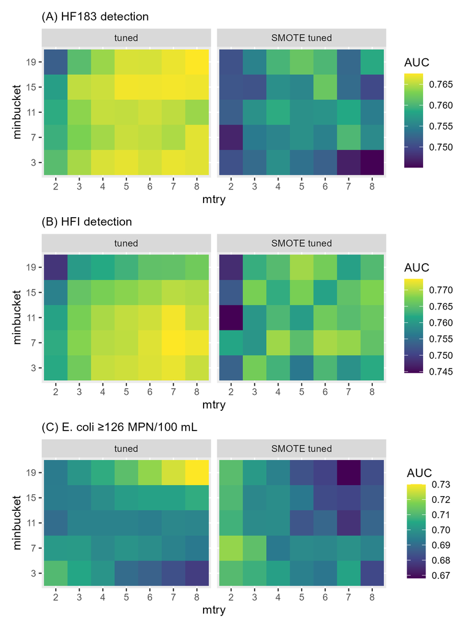

AUC in repeated 3-fold cross-validation from hyperparameter value combinations for raw (imbalanced) data and SMOTE-balanced data

### Benchmark performance

Compare model predictive performance between the untuned (raw data, default hyperparameters), tuned (raw data, optimized hyperparameters), and balanced (SMOTE data, SMOTE-tuned hyperparameters) models for each outcome using repeated cross-validation. Increase `ntrees` for stability and change the seed for variety.

```r
### HF183
## default
# learner
hf183_lrn_dflt <- setHyperPars(hf183_lrn, ntree = 10001)

# seed for reproducibility
set.seed(27599)

# perform cross-validation
hf183_bench_dflt <- repcv(learner = hf183_lrn_dflt,
                          task = hf183_task,
                          folds = 3L, reps = 5L,
                          measures = hparam_measure)


## tuned
# optimized params
hf183_opt <- readRDS("../fit/crf_tune_hf183.rds")$x

# learner
hf183_lrn_tune <- setHyperPars(hf183_lrn,
                               ntree = 10001,
                               mtry = hf183_opt$mtry,
                               minbucket = hf183_opt$minbucket)

# seed for reproducibility
set.seed(27599)

# perform cross-validation
hf183_bench_tune <- repcv(learner = hf183_lrn_tune,
                          task = hf183_task,
                          folds = 3L, reps = 5L,
                          measures = hparam_measure)


## smote
# optimized params
hf183_opt_smote <- readRDS("../fit/crf_tune_hf183_smote.rds")$x

# learner
hf183_lrn_tune_smote <- setHyperPars(hf183_lrn_smote,
                                     ntree = 10001,
                                     mtry = hf183_opt_smote$mtry,
                                     minbucket = hf183_opt_smote$minbucket)

# seed for reproducibility
set.seed(27599)

# perform cross-validation
hf183_bench_smote <- repcv(learner = hf183_lrn_tune_smote,
                           task = hf183_task,
                           folds = 3L, reps = 5L,
                           measures = hparam_measure)


### HFI
## default
# learner
hfi_lrn_dflt <- setHyperPars(hfi_lrn, ntree = 10001)

# seed for reproducibility
set.seed(27599)

# perform cross-validation
hfi_bench_dflt <- repcv(learner = hfi_lrn_dflt,
                        task = hfi_task,
                        folds = 3L, reps = 5L,
                        measures = hparam_measure)


## tuned
# optimized params
hfi_opt <- readRDS("../fit/crf_tune_hfi.rds")$x

# learner
hfi_lrn_tune <- setHyperPars(hfi_lrn,
                             ntree = 10001,
                             mtry = hfi_opt$mtry,
                             minbucket = hfi_opt$minbucket)

# seed for reproducibility
set.seed(27599)

# perform cross-validation
hfi_bench_tune <- repcv(learner = hfi_lrn_tune,
                        task = hfi_task,
                        folds = 3L, reps = 5L,
                        measures = hparam_measure)


## smote
# optimized params
hfi_opt_smote <- readRDS("../fit/crf_tune_hfi_smote.rds")$x

# learner
hfi_lrn_tune_smote <- setHyperPars(hfi_lrn_smote,
                                   ntree = 10001,
                                   mtry = hfi_opt_smote$mtry,
                                   minbucket = hfi_opt_smote$minbucket)

# seed for reproducibility
set.seed(27599)

# perform cross-validation
hfi_bench_smote <- repcv(learner = hfi_lrn_tune_smote,
                         task = hfi_task,
                         folds = 3L, reps = 5L,
                         measures = hparam_measure)


### ECOLI
## default
# learner
ecoli_lrn_dflt <- setHyperPars(ecoli_lrn, ntree = 10001)

# seed for reproducibility
set.seed(27599)

# perform cross-validation
ecoli_bench_dflt <- repcv(learner = ecoli_lrn_dflt,
                          task = ecoli_task,
                          folds = 3L, reps = 5L,
                          measures = hparam_measure)


## tuned
# optimized params
ecoli_opt <- readRDS("../fit/crf_tune_ecoli.rds")$x

# learner
ecoli_lrn_tune <- setHyperPars(ecoli_lrn,
                               ntree = 10001,
                               mtry = ecoli_opt$mtry,
                               minbucket = ecoli_opt$minbucket)

# seed for reproducibility
set.seed(27599)

# perform cross-validation
ecoli_bench_tune <- repcv(learner = ecoli_lrn_tune,
                          task = ecoli_task,
                          folds = 3L, reps = 5L,
                          measures = hparam_measure)


## smote
# optimized params
ecoli_opt_smote <- readRDS("../fit/crf_tune_ecoli_smote.rds")$x

# learner
ecoli_lrn_tune_smote <- setHyperPars(ecoli_lrn_smote,
                                     ntree = 10001,
                                     mtry = ecoli_opt_smote$mtry,
                                     minbucket = ecoli_opt_smote$minbucket)

# seed for reproducibility
set.seed(27599)

# perform cross-validation
ecoli_bench_smote <- repcv(learner = ecoli_lrn_tune_smote,
                           task = ecoli_task,
                           folds = 3L, reps = 5L,
                           measures = hparam_measure)

### Save Learners for later use
save(hf183_lrn, hf183_lrn_tune, hf183_lrn_smote, hf183_lrn_dflt,
     hfi_lrn, hfi_lrn_tune, hfi_lrn_smote, hfi_lrn_dflt,
     ecoli_lrn, ecoli_lrn_tune, ecoli_lrn_smote, ecoli_lrn_dflt,
     file = "../fit/learner_objs.RData")


### Combine and save
crf_bench <- bind_rows(
  hf183_bench_dflt$aggr %>%
    as_tibble_row() %>%
    mutate(outcome = "hf183", set = "dflt"),
  hf183_bench_tune$aggr %>%
    as_tibble_row() %>%
    mutate(outcome = "hf183", set = "tune"),
  hf183_bench_smote$aggr %>%
    as_tibble_row() %>%
    mutate(outcome = "hf183", set = "smote"),
  hfi_bench_dflt$aggr %>%
    as_tibble_row() %>%
    mutate(outcome = "hfi", set = "dflt"),
  hfi_bench_tune$aggr %>%
    as_tibble_row() %>%
    mutate(outcome = "hfi", set = "tune"),
  hfi_bench_smote$aggr %>%
    as_tibble_row() %>%
    mutate(outcome = "hfi", set = "smote"),
  ecoli_bench_dflt$aggr %>%
    as_tibble_row() %>%
    mutate(outcome = "ecoli", set = "dflt"),
  ecoli_bench_tune$aggr %>%
    as_tibble_row() %>%
    mutate(outcome = "ecoli", set = "tune"),
  ecoli_bench_smote$aggr %>%
    as_tibble_row() %>%
    mutate(outcome = "ecoli", set = "smote")
)

saveRDS(crf_bench, "../fit/crf_benchmark.rds")
```

Plot the mean and standard deviation AUC for each outcome and CRF tuning strategy.

```r
## Plot
p_bench <- readRDS("../fit/crf_benchmark.rds") %>%
  mutate(set = fct_relevel(set,
                           c("dflt", "tune", "smote")) %>%
           fct_recode("default" = "dflt",
                      "tuned" = "tune",
                      "SMOTE\n tuned" = "smote") %>%
           fct_rev(),
         outcome = fct_relevel(outcome,
                               c("hf183", "hfi", "ecoli")) %>%
           fct_recode("HF183 detection" = "hf183",
                      "HFI detection" = "hfi",
                      "E. coli ≥126" = "ecoli") %>%
           fct_rev()) %>%
  rename(auc = auc.testgroup.mean,
         auc_sd = auc.testgroup.sd) %>%
  ggplot(data = .,
         mapping = aes(x = auc, y = outcome, group = set, color = set)) +
  geom_pointrange(aes(xmin = (auc - auc_sd), xmax = (auc + auc_sd)),
                  position = position_dodge(width = 0.7)) +
  scale_color_viridis_d(name = "Hyperparameters",
                        end = 0.95, direction = -1) +
  guides(color = guide_legend(reverse = TRUE)) +
  labs(x = "AUC",
       y = NULL) +
  theme_bw() +
  theme(legend.key.height = unit(1.5, "lines"))


ggsave(filename = "../fig/crf_benchmark.png",
       plot = p_bench,
       device = ragg::agg_png, dpi = 300,
       width = 6, height = 3.5, units = "in")
```

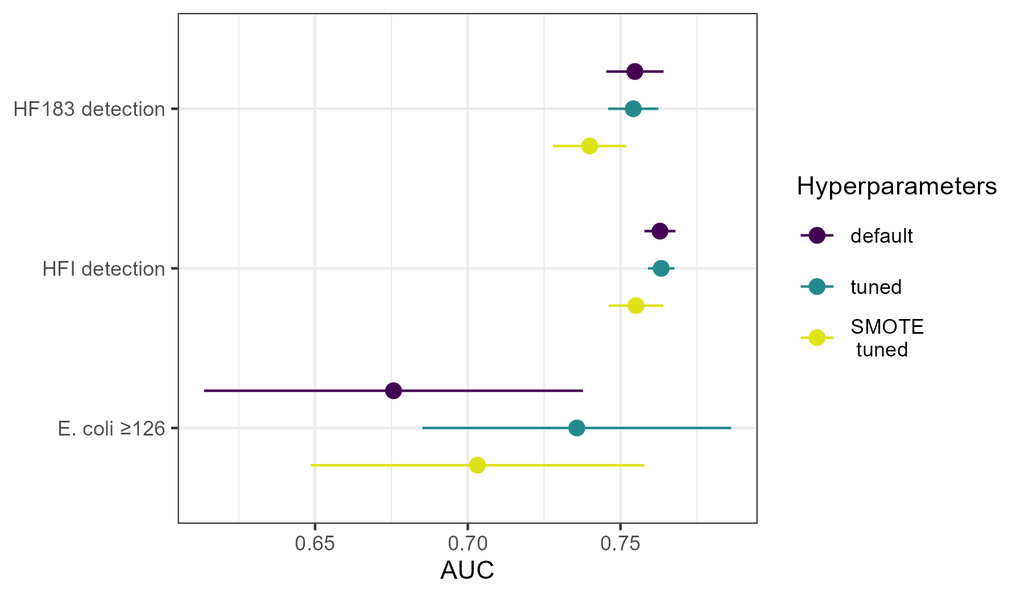

Mean ± SD area under the receiver operating characteristic curve (AUC) in repeated 3-fold cross-validation (5 iterations) on the training dataset for conditional random forest models by hyperparameter tuning strategy: default hyperparameters, tuned hyperparamters using grid search, and tuned hyperparamters after applying synthetic minority oversampling technique (SMOTE)

The discrimination, as measured by AUC, is nearly identical using the default hyperparameter values and the optimal tuned values for both HF183 and HFI. Models trained on SMOTE-adjusted data perform notably worse for both human-associated outcomes. For predicting elevated generic *E. coli*, however, the default values provide considerably worse performance than either tuning approach. Between the tuned models, SMOTE again offers inferior discrimination. Mean AUC is lower and the variance in AUC over cross-validation iterations much larger for all *E. coli* models than for either human outcome.

Although tuning improves the *E. coli* model performance, the values selected by tuning are at the extreme range of the search space for both hyperparameters: `mtry = 8` and `minbucket = 19`. This chasing of the extremes suggests some degenerate model behavior, particularly considering there are only 22 positive *E. coli* cases in the training dataset and only a dozen explanatory variables.

### Train

Perform the final model training for all three CRF variants (default, tuned, and SMOTE) on the full training dataset for each of the three outcomes.

```r
# Load learners
load("../fit/learner_objs.RData")


### HF183
## default
set.seed(30333)
hf183_train_dflt <- train(learner = hf183_lrn_dflt,
                          task = hf183_task)
saveRDS(hf183_train_dflt, "../fit/hf183_train_dflt.rds")

## tuned
set.seed(30333)
hf183_train_tune <- train(learner = hf183_lrn_tune,
                          task = hf183_task)
saveRDS(hf183_train_tune, "../fit/hf183_train_tune.rds")


## smote
set.seed(30333)
hf183_train_smote <- train(learner = hf183_lrn_tune_smote,
                           task = hf183_task)
saveRDS(hf183_train_smote, "../fit/hf183_train_smote.rds")


### HFI
## default
set.seed(30333)
hfi_train_dflt <- train(learner = hfi_lrn_dflt,
                        task = hfi_task)
saveRDS(hfi_train_dflt, "../fit/hfi_train_dflt.rds")

## tuned
set.seed(30333)
hfi_train_tune <- train(learner = hfi_lrn_tune,
                        task = hfi_task)
saveRDS(hfi_train_tune, "../fit/hfi_train_tune.rds")


## smote
set.seed(30333)
hfi_train_smote <- train(learner = hfi_lrn_tune_smote,
                         task = hfi_task)
saveRDS(hfi_train_smote, "../fit/hfi_train_smote.rds")



### ECOLI
## default
set.seed(30333)
ecoli_train_dflt <- train(learner = ecoli_lrn_dflt,
                          task = ecoli_task)
saveRDS(ecoli_train_dflt, "../fit/ecoli_train_dflt.rds")

## tuned
set.seed(30333)
ecoli_train_tune <- train(learner = ecoli_lrn_tune,
                          task = ecoli_task)
saveRDS(ecoli_train_tune, "../fit/ecoli_train_tune.rds")


## smote
set.seed(30333)
ecoli_train_smote <- train(learner = ecoli_lrn_tune_smote,
                           task = ecoli_task)
saveRDS(ecoli_train_smote, "../fit/ecoli_train_smote.rds")
```

#### Add *E. coli* predictor

As an additional analysis to investigate whether elevated generic *E. coli* levels help predict human fecal contamination, retrain the human outcome CRF models including elevated *E. coli* as an explanatory variable.

```r
## training data (all outcomes)
df_train_crf <- readRDS("../out/data_train.rds") %>%
  mutate(across(c(hf183, phage, hfi, ecoli, building),
                ~factor(.x, levels = c("0", "1"),
                        labels = c("0" = "neg", "1" = "pos")))) %>%
  select(week, building,
         turb, cond, do, ph,
         rain2, rain7,
         solar2,
         wind2, wind7,
         hf183, hfi, ecoli)



### HF183
## drop non-target vars
df_hf183_ec <- df_train_crf %>%
  select(-hfi)

## revise classification task
hf183_task_ec <- makeClassifTask(id = "hf183_ec",
                                 data = df_hf183_ec,
                                 target = "hf183",
                                 positive = "pos")

## default
# train
set.seed(30333)
hf183_train_dflt_ec <- train(learner = hf183_lrn_dflt,
                             task = hf183_task_ec)
saveRDS(hf183_train_dflt_ec, "../fit/hf183_train_dflt_ec.rds")

## tuned
set.seed(30333)
hf183_train_tune_ec <- train(learner = hf183_lrn_tune,
                             task = hf183_task_ec)
saveRDS(hf183_train_tune_ec, "../fit/hf183_train_tune_ec.rds")


## smote
set.seed(30333)
hf183_train_smote_ec <- train(learner = hf183_lrn_tune_smote,
                              task = hf183_task_ec)
saveRDS(hf183_train_smote_ec, "../fit/hf183_train_smote_ec.rds")


### HFI
## drop non-target vars
df_hfi_ec <- df_train_crf %>%
  select(-hf183)

## revise classification task
hfi_task_ec <- makeClassifTask(id = "hfi_ec",
                               data = df_hfi_ec,
                               target = "hfi",
                               positive = "pos")

## default
set.seed(30333)
hfi_train_dflt_ec <- train(learner = hfi_lrn_dflt,
                           task = hfi_task_ec)
saveRDS(hfi_train_dflt_ec, "../fit/hfi_train_dflt_ec.rds")

## tuned
set.seed(30333)
hfi_train_tune_ec <- train(learner = hfi_lrn_tune,
                           task = hfi_task_ec)
saveRDS(hfi_train_tune_ec, "../fit/hfi_train_tune_ec.rds")


## smote
set.seed(30333)
hfi_train_smote_ec <- train(learner = hfi_lrn_tune_smote,
                            task = hfi_task_ec)
saveRDS(hfi_train_smote_ec, "../fit/hfi_train_smote_ec.rds")
```

### Variable importance

*Note: this is a very slow computation.*

```r
### HF183
## default
hf183_imp_dflt <- getFeatureImportance(readRDS("../fit/hf183_train_dflt.rds"),
                                       conditional = TRUE,
                                       auc = TRUE)$res %>%
  mutate(outcome = "hf183",
         predvar = "slct",
         method = "dflt")

# with E. coli
hf183_imp_dflt_ec <- getFeatureImportance(readRDS("../fit/hf183_train_dflt_ec.rds"),
                                          conditional = TRUE,
                                          auc = TRUE)$res %>%
  mutate(outcome = "hf183",
         predvar = "ec_pred",
         method = "dflt")


## tuned
hf183_imp_tune <- getFeatureImportance(readRDS("../fit/hf183_train_tune.rds"),
                                       conditional = TRUE,
                                       auc = TRUE)$res %>%
  mutate(outcome = "hf183",
         predvar = "slct",
         method = "tune")

# with E. coli
hf183_imp_tune_ec <- getFeatureImportance(readRDS("../fit/hf183_train_tune_ec.rds"),
                                          conditional = TRUE,
                                          auc = TRUE)$res %>%
  mutate(outcome = "hf183",
         predvar = "ec_pred",
         method = "tune")


## smote
hf183_imp_smote <- getFeatureImportance(readRDS("../fit/hf183_train_smote.rds"),
                                        conditional = TRUE,
                                        auc = TRUE)$res %>%
  mutate(outcome = "hf183",
         predvar = "slct",
         method = "smote")

# with E. coli
hf183_imp_smote_ec <- getFeatureImportance(readRDS("../fit/hf183_train_smote_ec.rds"),
                                           conditional = TRUE,
                                           auc = TRUE)$res %>%
  mutate(outcome = "hf183",
         predvar = "ec_pred",
         method = "smote")


### HFI
## default
hfi_imp_dflt <- getFeatureImportance(readRDS("../fit/hfi_train_dflt.rds"),
                                       conditional = TRUE,
                                       auc = TRUE)$res %>%
  mutate(outcome = "hfi",
         predvar = "slct",
         method = "dflt")

# with E. coli
hfi_imp_dflt_ec <- getFeatureImportance(readRDS("../fit/hfi_train_dflt_ec.rds"),
                                          conditional = TRUE,
                                          auc = TRUE)$res %>%
  mutate(outcome = "hfi",
         predvar = "ec_pred",
         method = "dflt")


## tuned
hfi_imp_tune <- getFeatureImportance(readRDS("../fit/hfi_train_tune.rds"),
                                       conditional = TRUE,
                                       auc = TRUE)$res %>%
  mutate(outcome = "hfi",
         predvar = "slct",
         method = "tune")

# with E. coli
hfi_imp_tune_ec <- getFeatureImportance(readRDS("../fit/hfi_train_tune_ec.rds"),
                                          conditional = TRUE,
                                          auc = TRUE)$res %>%
  mutate(outcome = "hfi",
         predvar = "ec_pred",
         method = "tune")


## smote
hfi_imp_smote <- getFeatureImportance(readRDS("../fit/hfi_train_smote.rds"),
                                        conditional = TRUE,
                                        auc = TRUE)$res %>%
  mutate(outcome = "hfi",
         predvar = "slct",
         method = "smote")

# with E. coli
hfi_imp_smote_ec <- getFeatureImportance(readRDS("../fit/hfi_train_smote_ec.rds"),
                                           conditional = TRUE,
                                           auc = TRUE)$res %>%
  mutate(outcome = "hfi",
         predvar = "ec_pred",
         method = "smote")


### ECOLI
## default
ecoli_imp_dflt <- getFeatureImportance(readRDS("../fit/ecoli_train_dflt.rds"),
                                       conditional = TRUE,
                                       auc = TRUE)$res %>%
  mutate(outcome = "ecoli",
         predvar = "slct",
         method = "dflt")

## tuned
ecoli_imp_tune <- getFeatureImportance(readRDS("../fit/ecoli_train_tune.rds"),
                                       conditional = TRUE,
                                       auc = TRUE)$res %>%
  mutate(outcome = "ecoli",
         predvar = "slct",
         method = "tune")

## smote
ecoli_imp_smote <- getFeatureImportance(readRDS("../fit/ecoli_train_smote.rds"),
                                        conditional = TRUE,
                                        auc = TRUE)$res %>%
  mutate(outcome = "ecoli",
         predvar = "slct",
         method = "smote")


### Combine
imp_crf <- bind_rows(hf183_imp_dflt, hf183_imp_dflt_ec,
                     hf183_imp_tune, hf183_imp_tune_ec,
                     hf183_imp_smote, hf183_imp_smote_ec,
                     hfi_imp_dflt, hfi_imp_dflt_ec,
                     hfi_imp_tune, hfi_imp_tune_ec,
                     hfi_imp_smote, hfi_imp_smote_ec,
                     ecoli_imp_dflt,
                     ecoli_imp_tune,
                     ecoli_imp_smote) %>%
  select(method, predvar, outcome,
         term = variable,
         est = importance) %>%
  group_by(method, predvar, outcome) %>%
  mutate(est_max = max(est),
         est_min = min(est),
         est_range = est_max - est_min,
         est_norm = (est - est_min) / est_range) %>%
  ungroup()

saveRDS(imp_crf, "../out/varimp_crf.rds")
```

# Predictions

The final models have been trained for both regression and CRF approaches. Now predict the completely separate test dataset using the trained models to assess out-of-sample predictive performance.

## Regression

While the test dataset is used to assess predictive performance to avoid overfitting, the training dataset can also be predicted simultaneously to provide an idea of how much performance changes for in-sample vs. out of sample predictions.

```r
## stack training and test data, predict both
df_pred <- bind_rows(readRDS("../out/data_train.rds"),
                     readRDS("../out/data_test.rds"))


## HF183
# predict
pred_reg_183 <- df_pred %>%
  mutate(pred = predict(readRDS("../fit/reg_slct_hf183.rds"),
                        newdata = .,
                        allow.new.levels = TRUE,
                        type = "response")) %>%
  mutate(outcome = "hf183",
         predvar = "slct",
         method = "glmm") %>%
  select(set, dt_collect, pond,
         method, predvar, outcome,
         obs = hf183,
         pred)

# predict with E. coli
pred_reg_183_ec <- df_pred %>%
  mutate(pred = predict(readRDS("../fit/reg_ec_hf183.rds"),
                        newdata = .,
                        allow.new.levels = TRUE,
                        type = "response")) %>%
  mutate(outcome = "hf183",
         predvar = "ec_pred",
         method = "glmm") %>%
  select(set, dt_collect, pond,
         method, predvar, outcome,
         obs = hf183,
         pred)


## HFI
# predict
pred_reg_hfi <- df_pred %>%
  mutate(pred = predict(readRDS("../fit/reg_slct_hfi.rds"),
                        newdata = .,
                        allow.new.levels = TRUE,
                        type = "response")) %>%
  mutate(outcome = "hfi",
         predvar = "slct",
         method = "glmm") %>%
  select(set, dt_collect, pond,
         method, predvar, outcome,
         obs = hfi,
         pred)

# predict with E. coli
pred_reg_hfi_ec <- df_pred %>%
  mutate(pred = predict(readRDS("../fit/reg_ec_hfi.rds"),
                        newdata = .,
                        allow.new.levels = TRUE,
                        type = "response")) %>%
  mutate(outcome = "hfi",
         predvar = "ec_pred",
         method = "glmm") %>%
  select(set, dt_collect, pond,
         method, predvar, outcome,
         obs = hfi,
         pred)


## E. coli
# predict
pred_reg_ec <- df_pred %>%
  mutate(pred = predict(readRDS("../fit/reg_slct_ecoli.rds"),
                        newdata = .,
                        allow.new.levels = TRUE,
                        type = "response")) %>%
  mutate(outcome = "ecoli",
         predvar = "slct",
         method = "glmm") %>%
  select(set, dt_collect, pond,
         method, predvar, outcome,
         obs = ecoli,
         pred)


## Combine
pred_reg <- bind_rows(pred_reg_183,
                      pred_reg_183_ec,
                      pred_reg_hfi,
                      pred_reg_hfi_ec,
                      pred_reg_ec)

saveRDS(pred_reg, "../out/pred_reg.rds")
```

## Random forest

Generate predictions for training and test datasets for all variations of CRF models.

```r
### stack training and test data, predict both
df_pred_crf <- bind_rows(readRDS("../out/data_train.rds"),
                         readRDS("../out/data_test.rds")) %>%
  mutate(across(c(hf183, phage, hfi, ecoli, building),
                ~factor(.x, levels = c("0", "1"),
                        labels = c("0" = "neg", "1" = "pos"))))


### Function to process CRF predictions
predict_crf <- function(newdata, fit){

  pred <- predict(fit, newdata = newdata)

  pos <- newdata %>%
    bind_cols(pred$data) %>%
    rename(pred = prob.pos)

  return(pos)
}


### HF183
## default
hf183_pred_dflt <- df_pred_crf %>%
  predict_crf(readRDS("../fit/hf183_train_dflt.rds")) %>%
  mutate(outcome = "hf183",
         predvar = "slct",
         method = "dflt") %>%
  select(set, dt_collect, pond,
         method, predvar, outcome,
         obs = hf183,
         pred)

# with E. coli
hf183_pred_dflt_ec <- df_pred_crf %>%
  predict_crf(readRDS("../fit/hf183_train_dflt_ec.rds")) %>%
  mutate(outcome = "hf183",
         predvar = "ec_pred",
         method = "dflt") %>%
  select(set, dt_collect, pond,
         method, predvar, outcome,
         obs = hf183,
         pred)


## tuned
hf183_pred_tune <- df_pred_crf %>%
  predict_crf(readRDS("../fit/hf183_train_tune.rds")) %>%
  mutate(outcome = "hf183",
         predvar = "slct",
         method = "tune") %>%
  select(set, dt_collect, pond,
         method, predvar, outcome,
         obs = hf183,
         pred)

# with E. coli
hf183_pred_tune_ec <- df_pred_crf %>%
  predict_crf(readRDS("../fit/hf183_train_tune_ec.rds")) %>%
  mutate(outcome = "hf183",
         predvar = "ec_pred",
         method = "tune") %>%
  select(set, dt_collect, pond,
         method, predvar, outcome,
         obs = hf183,
         pred)


## smote
hf183_pred_smote <- df_pred_crf %>%
  predict_crf(readRDS("../fit/hf183_train_smote.rds")) %>%
  mutate(outcome = "hf183",
         predvar = "slct",
         method = "smote") %>%
  select(set, dt_collect, pond,
         method, predvar, outcome,
         obs = hf183,
         pred)

# with E. coli
hf183_pred_smote_ec <- df_pred_crf %>%
  predict_crf(readRDS("../fit/hf183_train_smote_ec.rds")) %>%
  mutate(outcome = "hf183",
         predvar = "ec_pred",
         method = "smote") %>%
  select(set, dt_collect, pond,
         method, predvar, outcome,
         obs = hf183,
         pred)



### HFI
## default
hfi_pred_dflt <- df_pred_crf %>%
  predict_crf(readRDS("../fit/hfi_train_dflt.rds")) %>%
  mutate(outcome = "hfi",
         predvar = "slct",
         method = "dflt") %>%
  select(set, dt_collect, pond,
         method, predvar, outcome,
         obs = hfi,
         pred)

# with E. coli
hfi_pred_dflt_ec <- df_pred_crf %>%
  predict_crf(readRDS("../fit/hfi_train_dflt_ec.rds")) %>%
  mutate(outcome = "hfi",
         predvar = "ec_pred",
         method = "dflt") %>%
  select(set, dt_collect, pond,
         method, predvar, outcome,
         obs = hfi,
         pred)


## tuned
hfi_pred_tune <- df_pred_crf %>%
  predict_crf(readRDS("../fit/hfi_train_tune.rds")) %>%
  mutate(outcome = "hfi",
         predvar = "slct",
         method = "tune") %>%
  select(set, dt_collect, pond,
         method, predvar, outcome,
         obs = hfi,
         pred)

# with E. coli
hfi_pred_tune_ec <- df_pred_crf %>%
  predict_crf(readRDS("../fit/hfi_train_tune_ec.rds")) %>%
  mutate(outcome = "hfi",
         predvar = "ec_pred",
         method = "tune") %>%
  select(set, dt_collect, pond,
         method, predvar, outcome,
         obs = hfi,
         pred)


## smote
hfi_pred_smote <- df_pred_crf %>%
  predict_crf(readRDS("../fit/hfi_train_smote.rds")) %>%
  mutate(outcome = "hfi",
         predvar = "slct",
         method = "smote") %>%
  select(set, dt_collect, pond,
         method, predvar, outcome,
         obs = hfi,
         pred)

# with E. coli
hfi_pred_smote_ec <- df_pred_crf %>%
  predict_crf(readRDS("../fit/hfi_train_smote_ec.rds")) %>%
  mutate(outcome = "hfi",
         predvar = "ec_pred",
         method = "smote") %>%
  select(set, dt_collect, pond,
         method, predvar, outcome,
         obs = hfi,
         pred)



### ECOLI
## default
ecoli_pred_dflt <- df_pred_crf %>%
  predict_crf(readRDS("../fit/ecoli_train_dflt.rds")) %>%
  mutate(outcome = "ecoli",
         predvar = "slct",
         method = "dflt") %>%
  select(set, dt_collect, pond,
         method, predvar, outcome,
         obs = ecoli,
         pred)


## tuned
ecoli_pred_tune <- df_pred_crf %>%
  predict_crf(readRDS("../fit/ecoli_train_tune.rds")) %>%
  mutate(outcome = "ecoli",
         predvar = "slct",
         method = "tune") %>%
  select(set, dt_collect, pond,
         method, predvar, outcome,
         obs = ecoli,
         pred)


## smote
ecoli_pred_smote <- df_pred_crf %>%
  predict_crf(readRDS("../fit/ecoli_train_smote.rds")) %>%
  mutate(outcome = "ecoli",
         predvar = "slct",
         method = "smote") %>%
  select(set, dt_collect, pond,
         method, predvar, outcome,
         obs = ecoli,
         pred)


## Combine
pred_crf <- bind_rows(hf183_pred_dflt, hf183_pred_dflt_ec,
                      hf183_pred_tune, hf183_pred_tune_ec,
                      hf183_pred_smote, hf183_pred_smote_ec,
                      hfi_pred_dflt, hfi_pred_dflt_ec,
                      hfi_pred_tune, hfi_pred_tune_ec,
                      hfi_pred_smote, hfi_pred_smote_ec,
                      ecoli_pred_dflt,
                      ecoli_pred_tune,
                      ecoli_pred_smote)

saveRDS(pred_crf, "../out/pred_crf.rds")
```

# Assess Performance

Receiver operating characteristic (ROC) curve analysis plots the true positive rate (sensitivity) against the false positive rate (1 - specificity) using each predicted probability as the threshold for classifying the prediction as positive. The area under the resulting curve provides a metric for the overall ability of the model to correctly classify predictions as positive and negative. The point on this curve with the greatest distance from the diagonal line (AUC = 0.5) corresponds to the predicted probability that maximizes the sum of sensitivity and specificity when used as the cutpoint to classify a prediction as positive or negative, called the Youden’s *J* statistic. For a pair of observations, one positive for the outcome and the other negative, the AUC corresponds to the proportion of such pairs that the model assigns a higher probability of the outcome to the positive observation.

All the predictions have been extracted as flat data frames and stacked, allowing operations to be applied across all model predictions in the same function calls. Generate ROC curves, calculate AUC, and extract the threshold value that maximizes Youden’s *J* for all models by iterating over dataset (training vs test), method (GLMM, default CRF, tuned CRF, SMOTE CRF), and explanatory variable set (selected variables or including elevated *E. coli* as a predictor).

```r
## combine predictions
pred_all <- bind_rows(
  readRDS("../out/pred_reg.rds") %>%
    mutate(obs = factor(obs, levels = c("0", "1"),
                        labels = c("0" = "neg", "1" = "pos"))),
  readRDS("../out/pred_crf.rds"))


## Calculate ROC by model and outcome
roc_all <- pred_all %>%
  group_by(set, method, predvar, outcome) %>%
  nest() %>%
  mutate(roc = map(data, ~pROC::roc(obs ~ pred, data = .x)),
         thresh = map(roc, ~pROC::coords(.x, x = "best", best.method = "youden")),
         diag = map(roc, ~pROC::ci.thresholds(.x, thresholds = "best", best.method = "youden")),
         auc = map(roc, ~pROC::auc(.x)),
         df = map(roc, ~pROC::ggroc(.x, legacy.axes = TRUE)$data)) %>%
  select(-data) %>%
  ungroup()

saveRDS(roc_all, "../out/roc_obj_all.rds")
```

# Plot

Generate plots of regression model coefficient estimates, random forest variable importance estimates, and ROC curves.

## Explanatory variables

Plot mode estimates of explanatory variable associations with the three binary outcomes: odds ratios derived from the logistic regression model coefficients and conditional variable importance from the random forest models.

### Regression coefficients

Plot odds ratios and 95% confidence intervals for each predictor variable included in the final multivariable logistic regression models, color coded by significance.

```r
## estimates
# variable names
var_lab <- read_xlsx("../data/variable_names.xlsx")

# raw
est_reg <- readRDS("../out/est_reg_slct.rds")

# format
df_plot_reg <- est_reg %>%
  filter(term %in% c("building", "rain2", "rain7", "solar2")) %>%
  left_join(var_lab, by = "term") %>%
  mutate(term = fct_relevel(term,
                             c("building", "rain2", "rain7", "solar2"))) %>%
  arrange(term) %>%
  mutate(label = fct_inorder(label) %>%
           fct_rev(),
         signif = case_when(p.value < 0.01 ~ "p < 0.01",
                            p.value >= 0.01 & p.value < 0.05 ~ "p < 0.05",
                            p.value >= 0.05 & p.value < 0.1 ~ "p < 0.1",
                            TRUE ~ NA_character_) %>%
           fct_relevel(c("p < 0.01", "p < 0.05", "p < 0.1")),
         out_lab = fct_relevel(outcome, c("hf183", "hfi", "ecoli")) %>%
           fct_recode("(A) HF183 detection" = "hf183",
                      "(B) HFI detection" = "hfi",
                      "(C) *E. coli* ≥126 MPN/100 mL" = "ecoli"))

p_or_all <- df_plot_reg %>%
  ggplot(aes(x = estimate, y = label, color = signif)) +
  facet_grid(cols = vars(out_lab)) +
  geom_vline(xintercept = 1, color = "red",
             linetype = "dashed", linewidth = 1,
             alpha = 0.5) +
  geom_point(shape = 18, size = 5) +
  geom_errorbarh(aes(xmin = conf.low, xmax = conf.high),
                 height = 0.15) +
  scale_x_log10(breaks = c(0.01, 0.1, 1, 10, 100),
                labels = c("0.01", "0.1", "1", "10", "100")) +
  scale_color_viridis_d(begin = 0.05, end = 0.95,
                        option = "plasma", direction = 1,
                        name = "Significance") +
  labs(x = "odds ratio",
       y = NULL) +
  theme_bw() +
  theme(strip.text = ggtext::element_markdown(hjust = 0),
        legend.position = "top",
        panel.spacing = unit(0.5, "lines"))


ggsave(filename = "../fig/forest_or.jpg",
       plot = p_or_all,
       device = ragg::agg_jpeg, dpi = 300,
       width = 8, height = 4, units = "in")
```

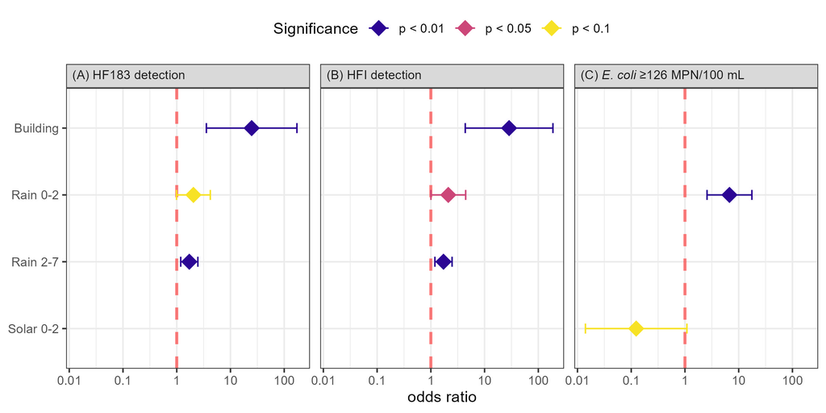

Odds ratio estimates and 95% CIs for explanatory varibales in final logistic regression models.

### Variable importance

Similarly, plot the variable importance from the random forest models. Focus on the default hyperparameter models without *E. coli* as a predictor for simplicity.

```r
## estimates
# variable names
var_lab <- read_xlsx("../data/variable_names.xlsx")

# raw
est_crf <- readRDS("../out/varimp_crf.rds")

# format
df_plot_crf <- est_crf %>%
  left_join(var_lab, by = "term") %>%
  filter(method == "dflt",
         predvar == "slct") %>%
  mutate(out_lab = fct_relevel(outcome, c("hf183", "hfi", "ecoli")) %>%
           fct_recode("(A) HF183 detection" = "hf183",
                      "(B) HFI detection" = "hfi",
                      "(C) *E. coli* ≥126 MPN/100 mL" = "ecoli"),
         est_norm = est_norm * 100)


## HF183
p_import_183 <- df_plot_crf %>%
  filter(outcome == "hf183") %>%
  arrange(est) %>%
  mutate(label = fct_inorder(label) %>%
           fct_recode("Dissolved\noxygen" = "Dissolved oxygen")) %>%
  ggplot(aes(x = est, y = label)) +
  facet_grid(cols = vars(out_lab)) +
  geom_vline(xintercept = 0, color = "red",
             linetype = "dashed", linewidth = 1,
             alpha = 0.5) +
  geom_point(shape = 18, size = 4) +
  labs(x = "conditional variable importance",
       y = NULL) +
  theme_bw() +
  theme(strip.text = ggtext::element_markdown(hjust = 0))

## HFI
p_import_hfi <- df_plot_crf %>%
  filter(outcome == "hfi") %>%
  arrange(est) %>%
  mutate(label = fct_inorder(label) %>%
           fct_recode("Dissolved\noxygen" = "Dissolved oxygen")) %>%
  ggplot(aes(x = est, y = label)) +
  facet_grid(cols = vars(out_lab)) +
  geom_vline(xintercept = 0, color = "red",
             linetype = "dashed", linewidth = 1,
             alpha = 0.5) +
  geom_point(shape = 18, size = 4) +
  labs(x = "conditional variable importance",
       y = NULL) +
  theme_bw() +
  theme(strip.text = ggtext::element_markdown(hjust = 0))


## E. coli
p_import_ec <- df_plot_crf %>%
  filter(outcome == "ecoli") %>%
  arrange(est) %>%
  mutate(label = fct_inorder(label) %>%
           fct_recode("Dissolved\noxygen" = "Dissolved oxygen")) %>%
  ggplot(aes(x = est, y = label)) +
  facet_grid(cols = vars(out_lab)) +
  geom_vline(xintercept = 0, color = "red",
             linetype = "dashed", linewidth = 1,
             alpha = 0.5) +
  geom_point(shape = 18, size = 4) +
  labs(x = "conditional variable importance",
       y = NULL) +
  theme_bw() +
  theme(strip.text = ggtext::element_markdown(hjust = 0))



## Combine

p_import <- p_import_183 + p_import_hfi + p_import_ec +
  plot_layout(ncol = 3, axis_titles = "collect")


ggsave(filename = "../fig/varimp_dflt.jpg",
       plot = p_import,
       device = ragg::agg_jpeg, dpi = 300,
       width = 9.5, height = 4.5, units = "in")
```

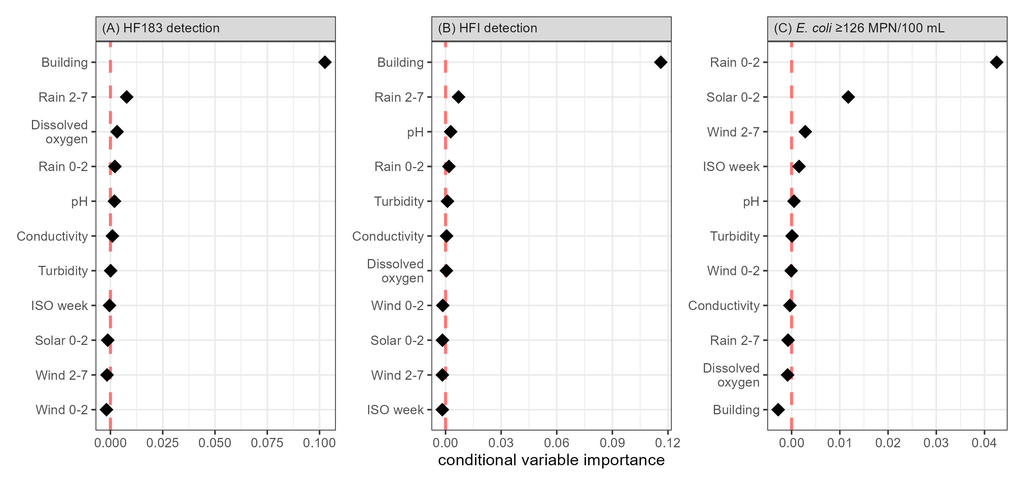

AUC-based conditional variable importance from conditional random forest models with default hyperparameters)

## ROC curves

Again, focusing only on the models without *E. coli* as a predictor, using default hyperparameters for CRF models. Look at ROC curves for training and test data separately.

### Test data

Plot ROC curves for test dataset predictions and augment with the threshold probability that maximizes the Youden’s *J* statistic (minimizes total misclassification) and the sensitivity and specificity at that threshold.

```r
## All ROC info
roc_test <- readRDS("../out/roc_obj_all.rds") %>%
  ungroup() %>%
  filter(set == "test",
         method %in% c("glmm", "dflt"),
         predvar == "slct") %>%
  mutate(outcome = fct_relevel(outcome, c("hf183", "hfi", "ecoli")) %>%
           fct_recode("(A) HF183 detection" = "hf183",
                      "(B) HFI detection" = "hfi",
                      "(C) *E. coli* ≥126 MPN/100 mL" = "ecoli"),
         method = fct_relevel(method, c("glmm", "dflt")) %>%
           fct_recode("Conditional\nRandom Forest" = "dflt",
                      "Logistic\nRegression" = "glmm"))


## roc data for plot
df_roc_test <- roc_test %>%
  select(set, method, outcome,
         df) %>%
  unnest(df)

## Other metrics
df_perf_test <- roc_test %>%
  ungroup() %>%
  select(set, method, outcome,
         auc, thresh) %>%
  unnest(thresh) %>%
  mutate(auc = unlist(auc),
         auc_lab = str_c("AUC: ", broman::myround(auc, 2)),
         perf_lab = str_c(auc_lab, "\n",
                          "threshold: ", broman::myround(threshold, 2), "\n",
                          "sensitivity: ", broman::myround(sensitivity, 2), "\n",
                          "specificity: ", broman::myround(specificity, 2)),
         `1-specificity` = 1 - specificity)

# plot ROC curves
p_roc_test <- df_roc_test %>%
  #mutate(across(c(`1-specificity`, sensitivity), ~.x * 100)) %>%
  ggplot(aes(x = `1-specificity`, y = sensitivity)) +
  facet_grid(rows = vars(method), cols = vars(outcome)) +
  geom_abline(intercept = 0, slope = 1,
              linetype = "dashed", linewidth = 1,
              color = "red", alpha = 0.6) +
  geom_line(linewidth = 1.25) +
  geom_point(data = df_perf_test,
             size = 3, color = "#205493", alpha = 0.9) +
  geom_text(aes(x = .55, y = .45, label = perf_lab),
            data = df_perf_test,
            size = 3,
            hjust = 0, vjust = 1) +
  coord_equal() +
  scale_x_continuous(breaks = c(0, 0.25, 0.5, 0.75, 1),
                     labels = c("0", "0.25", "0.5", "0.75", "1")) +
  scale_y_continuous(breaks = c(0, 0.25, 0.5, 0.75, 1),
                     labels = c("0", "0.25", "0.5", "0.75", "1")) +
  theme_bw() +
  theme(strip.text.x = ggtext::element_markdown(hjust = 0))

ggsave(filename = "../fig/roc_curves_test.jpg",
       plot = p_roc_test,
       device = ragg::agg_jpeg, dpi = 300,
       width = 8, height = 5.5, units = "in")
```

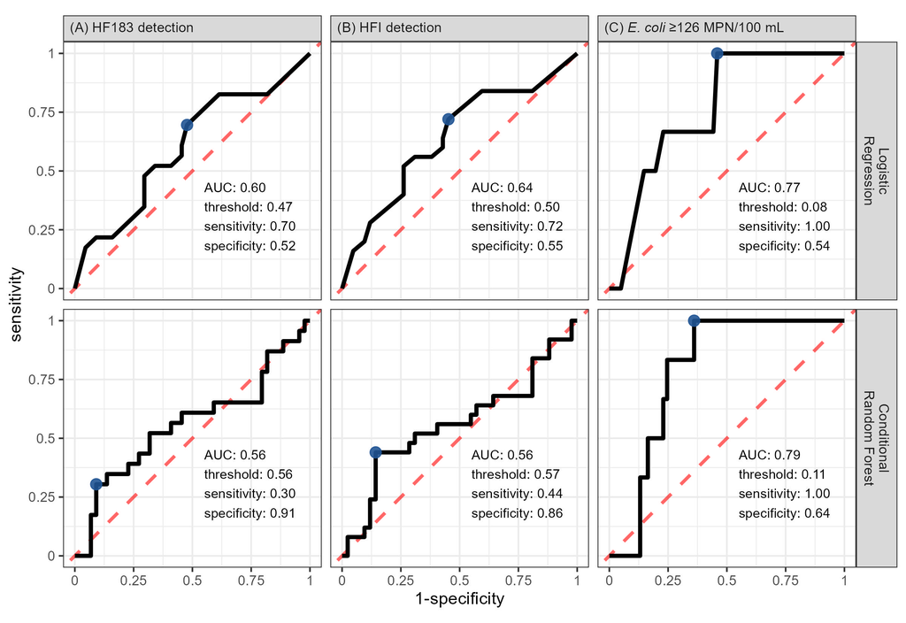

ROC curves for predicting the test dataset (default hyperparameters for CRF models)

### Training data

For context, also plot the ROC curves and thresholds for predictions on the training dataset.

```r
## All ROC info
roc_train <- readRDS("../out/roc_obj_all.rds") %>%
  ungroup() %>%
  filter(set == "train",
         method %in% c("glmm", "dflt"),
         predvar == "slct") %>%
  mutate(outcome = fct_relevel(outcome, c("hf183", "hfi", "ecoli")) %>%
           fct_recode("(A) HF183 detection" = "hf183",
                      "(B) HFI detection" = "hfi",
                      "(C) *E. coli* ≥126 MPN/100 mL" = "ecoli"),
         method = fct_relevel(method, c("glmm", "dflt")) %>%
           fct_recode("Conditional\nRandom Forest" = "dflt",
                      "Logistic\nRegression" = "glmm"))


## roc data for plot
df_roc_train <- roc_train %>%
  select(set, method, outcome,
         df) %>%
  unnest(df)

## Other metrics
df_perf_train <- roc_train %>%
  ungroup() %>%
  select(set, method, outcome,
         auc, thresh) %>%
  unnest(thresh) %>%
  mutate(auc = unlist(auc),
         auc_lab = str_c("AUC: ", broman::myround(auc, 2)),
         perf_lab = str_c(auc_lab, "\n",
                          "threshold: ", broman::myround(threshold, 2), "\n",
                          "sensitivity: ", broman::myround(sensitivity, 2), "\n",
                          "specificity: ", broman::myround(specificity, 2)),
         `1-specificity` = 1 - specificity)

# plot ROC curves
p_roc_train <- df_roc_train %>%
  #mutate(across(c(`1-specificity`, sensitivity), ~.x * 100)) %>%
  ggplot(aes(x = `1-specificity`, y = sensitivity)) +
  facet_grid(rows = vars(method), cols = vars(outcome)) +
  geom_abline(intercept = 0, slope = 1,
              linetype = "dashed", linewidth = 1,
              color = "red", alpha = 0.6) +
  geom_line(linewidth = 1.25) +
  geom_point(data = df_perf_train,
             size = 3, color = "#205493", alpha = 0.9) +
  geom_text(aes(x = .55, y = .45, label = perf_lab),
            data = df_perf_train,
            size = 3,
            hjust = 0, vjust = 1) +
  coord_equal() +
  scale_x_continuous(breaks = c(0, 0.25, 0.5, 0.75, 1),
                     labels = c("0", "0.25", "0.5", "0.75", "1")) +
  scale_y_continuous(breaks = c(0, 0.25, 0.5, 0.75, 1),
                     labels = c("0", "0.25", "0.5", "0.75", "1")) +
  theme_bw() +
  theme(strip.text.x = ggtext::element_markdown(hjust = 0))

ggsave(filename = "../fig/roc_curves_train.png",
       plot = p_roc_train,
       device = ragg::agg_png, dpi = 300,
       width = 8, height = 5.5, units = "in")
```

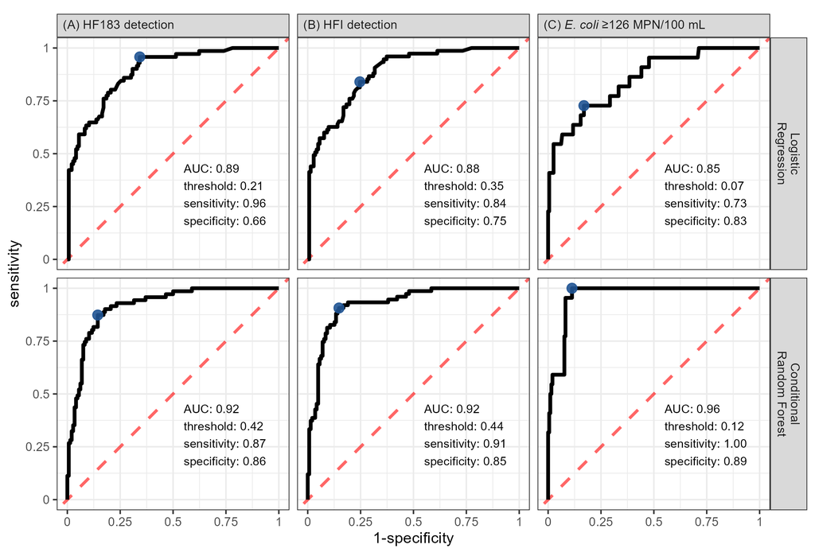

ROC curves for predicting the training dataset (default hyperparameters for CRF models)

### Human with *E. coli*

Also compare the predictions of the human markers with and without using an indicator of elevated *E. coli* as a predictor.

```r
## All ROC info
roc_obj_ec <- readRDS("../out/roc_obj_all.rds") %>%
  ungroup() %>%
  filter(set == "test",
         method %in% c("glmm", "dflt"),
         outcome %in% c("hf183", "hfi")) %>%
  mutate(outcome = fct_relevel(outcome, c("hf183", "hfi")) %>%
           fct_recode("HF183 detection" = "hf183",
                      "HFI detection" = "hfi"),
         method = fct_relevel(method, c("glmm", "dflt")) %>%
           fct_recode("Conditional\nRandom Forest" = "dflt",
                      "Logistic\nRegression" = "glmm"),
         predvar = fct_recode(predvar,
                              "Original model" = "slct",
                              "*E. coli* predictor added" = "ec_pred") %>%
           fct_relevel(c("Original model", "*E. coli* predictor added")))

## roc data for plot
df_roc_ec <- roc_obj_ec %>%
  select(set, method, predvar, outcome,
         df) %>%
  unnest(df)

## Other metrics
df_perf_ec <- roc_obj_ec %>%
  ungroup() %>%
  select(set, method, predvar, outcome,
         auc, thresh) %>%
  unnest(thresh) %>%
  mutate(auc = unlist(auc),
         auc_lab = str_c("AUC: ", broman::myround(auc, 2)),
         perf_lab = str_c(auc_lab, "\n",
                          "threshold: ", broman::myround(threshold, 2), "\n",
                          "sensitivity: ", broman::myround(sensitivity, 2), "\n",
                          "specificity: ", broman::myround(specificity, 2)),
         `1-specificity` = 1 - specificity)


## Plot
p_roc_ec <- df_roc_ec %>%
  ggplot(aes(x = `1-specificity`, y = sensitivity)) +
  facet_nested(rows = vars(method),
               cols = vars(outcome, predvar)) +
  geom_abline(intercept = 0, slope = 1,
              linetype = "dashed", linewidth = 1,
              color = "red", alpha = 0.6) +
  geom_line(linewidth = 1.25) +
  geom_point(data = df_perf_ec,
             size = 3, color = "#205493", alpha = 0.9) +
  geom_text(aes(x = .55, y = .45, label = perf_lab),
            data = df_perf_ec,
            size = 3,
            hjust = 0, vjust = 1) +
  coord_equal() +
  scale_x_continuous(breaks = c(0, 0.25, 0.5, 0.75, 1),
                     labels = c("0", "0.25", "0.5", "0.75", "1")) +
  scale_y_continuous(breaks = c(0, 0.25, 0.5, 0.75, 1),
                     labels = c("0", "0.25", "0.5", "0.75", "1")) +
  theme_bw() +
  theme(strip.text.x = ggtext::element_markdown())


ggsave(filename = "../fig/roc_human_ecpred_nest.png",
       plot = p_roc_ec,
       device = ragg::agg_png, dpi = 300,
       width = 10, height = 5.5, units = "in")
```

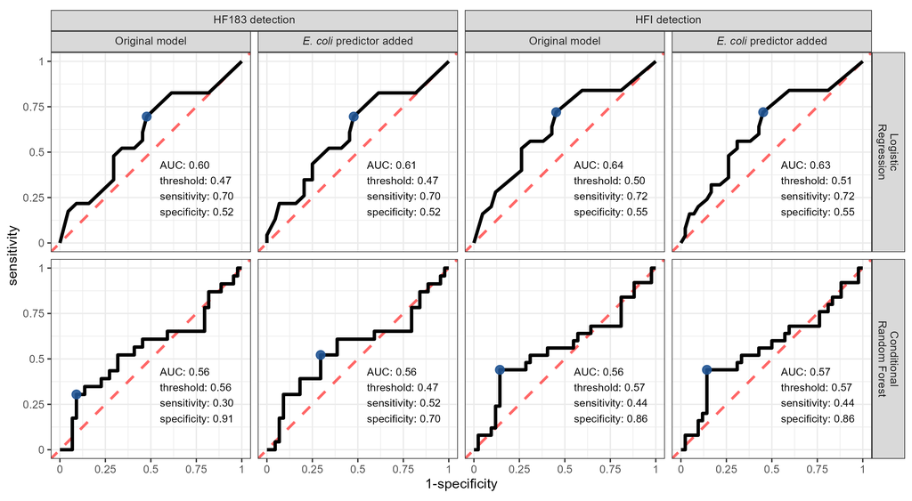

ROC curves for predicting the test dataset human outcomes with and without an indicator of elevated generic E. coli* levels as an explanatory variable (default hyperparameters for CRF models)

### Tuning comparison

Finally, compare the predictive performance of the CRF models using different hyperparameter tuning and class imbalance correction strategies for both the training and test datasets.

```r
## All ROC info
roc_obj_tune <- readRDS("../out/roc_obj_all.rds") %>%
  ungroup() %>%
  filter(method != "glmm",
         predvar == "slct") %>%
  mutate(outcome = fct_relevel(outcome, c("hf183", "hfi", "ecoli")) %>%
           fct_recode("HF183 detection" = "hf183",
                      "HFI detection" = "hfi",
                      "*E. coli* ≥126 MPN/100 mL" = "ecoli"),
         method = fct_relevel(method, c("dflt", "tune", "smote")) %>%
           fct_recode("default" = "dflt",
                      "tuned" = "tune",
                      "SMOTE tuned" = "smote"),
         set = fct_relevel(set, c("train", "test")) %>%
           fct_recode("training data" = "train",
                      "test data" = "test"),
         hyper = "Hyperparameters")


## roc data for plot
df_roc_tune <- roc_obj_tune %>%
  select(set, hyper, method, predvar, outcome,
         df) %>%
  unnest(df)

## Other metrics
df_perf_tune <- roc_obj_tune %>%
  ungroup() %>%
  select(set, hyper, method, predvar, outcome,
         auc, thresh) %>%
  unnest(thresh) %>%
  mutate(auc = unlist(auc),
         auc_lab = str_c("AUC: ", broman::myround(auc, 2)),
         perf_lab = str_c(auc_lab),
         `1-specificity` = 1 - specificity)


## Plot
p_roc_tune <- df_roc_tune %>%
  ggplot(aes(x = `1-specificity`, y = sensitivity)) +
  facet_nested(rows = vars(hyper, method),
               cols = vars(outcome, set)) +
  geom_abline(intercept = 0, slope = 1,
              linetype = "dashed", linewidth = 1,
              color = "red", alpha = 0.6) +
  geom_line(linewidth = 1.25) +
  geom_text(aes(x = .55, y = .45, label = perf_lab),
            data = df_perf_tune,
            size = 3,
            hjust = 0, vjust = 1) +
  coord_equal() +
  scale_x_continuous(breaks = c(0, 0.25, 0.5, 0.75, 1),
                     labels = c("0", "0.25", "0.5", "0.75", "1")) +
  scale_y_continuous(breaks = c(0, 0.25, 0.5, 0.75, 1),
                     labels = c("0", "0.25", "0.5", "0.75", "1")) +
  theme_bw() +
  theme(strip.text.x = ggtext::element_markdown(),
        panel.spacing = unit(0.2, "lines"))


ggsave(filename = "../fig/roc_crf_tune.png",
       plot = p_roc_tune,
       device = ragg::agg_png, dpi = 300,
       width = 10, height = 5.5, units = "in")
```

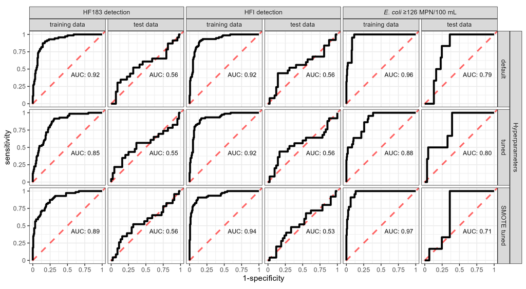

ROC curves for predictions of both the full training set and test dataset by conditional random forest models trained using different hyperparameter tuning strategies: default hyperparameters, tuned hyperparamters using grid search, and tuned hyperparamters after applying synthetic minority oversampling technique (SMOTE)

**Disclaimer:**

The findings and conclusions of this report are those of the authors and do not necessarily represent the official position of the Centers for Disease Control and Prevention.

# References

1.

Hothorn T, Hornik K, Zeileis A. Unbiased recursive partitioning: A conditional inference framework. *Journal of Computational and Graphical Statistics* **2006**, *15* (3), 651–674. https://doi.org/10.1198/106186006X133933.

2.

Strobl C, Malley J, Tutz G. An introduction to recursive partitioning: Rationale, application, and characteristics of classification and regression trees, bagging, and random forests. *Psychological Methods* **2009**, *14* (4), 323–348. https://doi.org/10.1037/a0016973.

3.

Bischl B, Lang M, Kotthoff L, Schiffner J, Richter J, Studerus E, Casalicchio G, Jones ZM. mlr: Machine learning in R. *Journal of Machine Learning Research* **2016**, *17* (170), 1–5. http://jmlr.org/papers/v17/15-066.html.

4.

Weller DL, Love TMT, Wiedmann M. Comparison of resampling algorithms to address class imbalance when developing machine learning models to predict foodborne pathogen presence in agricultural water. *Frontiers in Environmental Science* **2021**, *9*, 701288. https://doi.org/10.3389/fenvs.2021.701288.

5.

Kim M, Hwang K-B. An empirical evaluation of sampling methods for the classification of imbalanced data. *PLOS ONE* **2022**, *17* (7), e0271260. https://doi.org/10.1371/journal.pone.0271260.

6.

Van Den Goorbergh R, Van Smeden M, Timmerman D, Van Calster B. The harm of class imbalance corrections for risk prediction models: illustration and simulation using logistic regression. *Journal of the American Medical Informatics Association* **2022**, *29* (9), 1525–1534. https://doi.org/10.1093/jamia/ocac093.

7.

Cartus AR, Bodnar LM, Naimi AI. The impact of undersampling on the predictive performance of logistic regression and machine learning algorithms: A simulation study. *Epidemiology* **2020**, *31* (5), e42–e44. https://doi.org/10.1097/EDE.0000000000001198.

8.

Carriero A, Luijken K, de Hond A, Moons KG, van Calster B, van Smeden M. The harms of class imbalance corrections for machine learning based prediction models: a simulation study. *arXiv [preprint]* **2024**. https://doi.org/10.48550/ARXIV.2404.19494.

9.

Chawla NV, Bowyer KW, Hall LO, Kegelmeyer WP. SMOTE: Synthetic minority over-sampling technique. *Journal of Artificial Intelligence Research* **2002**, *16*, 321–357. https://doi.org/10.1613/jair.953.

10.

Strobl C, Boulesteix A-L, Kneib T, Augustin T, Zeileis A. Conditional variable importance for random forests. *BMC Bioinformatics* **2008**, *9* (1), 307. https://doi.org/10.1186/1471-2105-9-307.

11.

Janitza S, Strobl C, Boulesteix A-L. An AUC-based permutation variable importance measure for random forests. *BMC Bioinformatics* **2013**, *14* (1), 119. https://doi.org/10.1186/1471-2105-14-119.

12.

Strobl C, Boulesteix A-L, Zeileis A, Hothorn T. Bias in random forest variable importance measures: Illustrations, sources and a solution. *BMC Bioinformatics* **2007**, *8* (1), 25. https://doi.org/10.1186/1471-2105-8-25.